# 1BM110 - Assignment 2 - Group 8

Authors:

- Twan Vredendaal (1438905);
- Bram Oliemeulen (1317091);
- Andrea Domini (2102404);
- Maksim Kolk (1891626);

# 0. Premises

The structure of this report has been designed to enhance clarity and comprehension of the presented information. To ensure effective communication, an approach involving repetition of certain sections or significant parts has been adopted in both sections of the report. This decision has been made to provide readers with a clear and detailed view of the contents without the need for frequent cross-referencing between the two sections of the report.

The repetition of certain sections, while it may appear redundant, has been deemed necessary to ensure that each part of the report is self-contained and understandable even when read in isolation. Additionally, it allows readers to focus on relevant information without continually needing to refer back to other sections of the report.

# 1. Introduction

The planning of energy supply and consumption has become increasingly important lately, where fossil energy sources eventually must be phased out, while the risk of running short of energy should be avoided at all times. As a result, it is very important to construct a clear and viable forecast for the generation of renewable energy sources like onshore windfarms, in order to facilitate a sustainable and complete energy balance in the future.

To accomplish this in particular for onshore windfarms, two different models are developed. The first model, model A, is a supervised regression model, built on response features that are created from the available data. It is a neural network model and the features are not time-dependent. Then, for model B, time-dependent sequences are used to develop a time series forecast using a recurrent neural network architecture.

# 2. Methods

##### Data Collection and Pre-processing

The data utilized in this study consists of energy generation records spanning from August 2022 to February 2024. Two separate datasets were provided: one for model training (energy_generation_train.csv) and another for testing (energy_generation_test.csv), therefore splitting data into training and testing sets is not necessary. Both datasets encompass the energy generated every 15 minutes across the country from 21 different sources. Upon loading the datasets, initial data exploration revealed potential data cleaning requirements. This included checking for missing values and outliers, crucial for ensuring the integrity of subsequent analyses. Descriptive statistics were computed to identify any irregularities in the data distribution.

##### Feature Engineering

In preparation for Model A, features were engineered to encapsulate temporal patterns and potential predictors of onshore wind energy generation. These included temporal attributes such as day of the week and month, which may capture seasonality effects. Additionally, features based on frequency distribution and more advanced response features, for example, based on change points were implemented. For Model B, the data was organized into time-dependent sequences suitable for time series forecasting. Each sequence contained the energy generated by all sources at each time step, with the target variable being the energy generated by onshore wind at the subsequent time step.

##### Model Development and Evaluation

Now, the first thing to do is importing all the libraries that are used for both model A and B, as well as for the intermediate steps. This is performed below.

```python
import pandas as pd
import numpy as np
import matplotlib.pyplot as plt
import seaborn as sns
from sklearn.preprocessing import StandardScaler
from scipy.stats import shapiro
from sklearn.preprocessing import LabelEncoder, MinMaxScaler, StandardScaler
from sklearn.linear_model import LinearRegression
from sklearn.model_selection import KFold
from tensorflow.keras.models import Sequential
from tensorflow.keras.layers import Dense, Activation, Dropout, Input, LSTM
from sklearn.model_selection import GridSearchCV, KFold
from sklearn.metrics import mean_squared_error, mean_absolute_error, r2_score
from tensorflow.keras.optimizers import Adam
from tensorflow import keras
from keras.models import Model
from keras.layers import Input, Dense, LSTM
from keras.optimizers import Adam
from pandas import DataFrame
from pandas import concat
from tensorflow.keras.models import Sequential
from tensorflow.keras.layers import Dense, Input
```

# 3. Model A

## A1: Data pre-processing

There are four phases which need to be done when preparing your data. This following four steps are:

1. Data integration (A1.1, B1.1)
2. Data cleaning (A1.2, B1.2)
3. Data reduction (not needed for our dataset, since we take the entire dataset and do not need to sample)
4. Data transformation (A1.3 and B1.3 are treated separately)

### A1.1: The data is aggregated into a daily frequency

In this section, the code outlines the process of transforming the dataset into a daily frequency, which is essential for predictive modelling. Here's a brief overview of the steps involved:

- Data Type Evaluation and Conversion: initially, the code assesses the data types within the training and test datasets to ensure consistency. If needed, the "DateTime" column is converted to datetime format for accurate temporal analysis.
- Aggregation into Daily Frequency (Training and Test): Next, the datasets are indexed by the "DateTime" column to facilitate time-based operations. Using the resample('D').sum() function, the data is aggregated into daily intervals by summing up the values for each day. This aggregation is crucial for predicting daily patterns and trends.
- Result Verification: Finally, the resulting datasets are inspected to verify the successful transformation into daily frequency. This ensures that the data is properly prepared for subsequent predictive modeling tasks.

By following these steps, the code ensures that the dataset is structured in a manner conducive to daily frequency prediction. This preprocessing step lays the foundation for accurate and meaningful predictive modeling insights.

So, starting in the cell below, the training data and test data are uploaded in the program.

```python
# data uploading (training)
df_train_upload = pd.read_csv('energy_generation_train.csv')
df_train_upload.head()

# data uploading (test)
df_test_upload = pd.read_csv('energy_generation_test.csv')
df_test_upload.head()
```

|  | DateTime | Biomass | Fossil Brown coal/Lignite | Fossil Coal-derived gas | Fossil Gas | Fossil Hard coal | Fossil Oil | Fossil Oil shale | Fossil Peat | Geothermal | ... | Hydro Run-of-river and poundage | Hydro Water Reservoir | Marine | Nuclear | Other | Other renewable | Solar | Waste | Wind Offshore | Wind Onshore |
| --- | --- | --- | --- | --- | --- | --- | --- | --- | --- | --- | --- | --- | --- | --- | --- | --- | --- | --- | --- | --- | --- |
| 0 | 2023-09-01 00:00:00 | 0.0 | NaN | NaN | 6645.0 | 582.0 | NaN | NaN | NaN | NaN | ... | 0.0 | NaN | NaN | 470.0 | 250.0 | NaN | 0.0 | 72.0 | 233.0 | 33.0 |
| 1 | 2023-09-01 00:15:00 | 0.0 | NaN | NaN | 6628.0 | 572.0 | NaN | NaN | NaN | NaN | ... | 0.0 | NaN | NaN | 470.0 | 221.0 | NaN | 0.0 | 71.0 | 204.0 | 26.0 |
| 2 | 2023-09-01 00:30:00 | 0.0 | NaN | NaN | 6499.0 | 579.0 | NaN | NaN | NaN | NaN | ... | 0.0 | NaN | NaN | 470.0 | 209.0 | NaN | 0.0 | 72.0 | 212.0 | 33.0 |
| 3 | 2023-09-01 00:45:00 | 0.0 | NaN | NaN | 6392.0 | 579.0 | NaN | NaN | NaN | NaN | ... | 0.0 | NaN | NaN | 470.0 | 210.0 | NaN | 0.0 | 72.0 | 253.0 | 38.0 |
| 4 | 2023-09-01 01:00:00 | 0.0 | NaN | NaN | 6352.0 | 583.0 | NaN | NaN | NaN | NaN | ... | 0.0 | NaN | NaN | 471.0 | 203.0 | NaN | 0.0 | 72.0 | 226.0 | 37.0 |

5 rows × 22 columns

Then, starting with the training data, the data types are observed. All data types that are float64, which are all columns except for DateTime, are satisfying. However, since the DataTime is an object, this is changed. Afterwards, the type is datetime64.

```python
# data integration

# data type evaluation (training)
datatypes_train = df_train_upload.dtypes
#print(datatypes_train)

# datatype change
df_train_upload["DateTime"] = pd.to_datetime(df_train_upload["DateTime"])
```

Moreover, for the test data, exactly the same is done. Datatypes are checked, whereafter the type of the DateTime is changed again.

```python
# data type evaluation (test)
datatypes_test = df_test_upload.dtypes
#print(datatypes_test)

# datatype change
df_test_upload["DateTime"] = pd.to_datetime(df_test_upload["DateTime"])
```

```python
# daily aggregation (training)

df_train_index = df_train_upload.copy()
df_train_index.set_index('DateTime', inplace=True)
df_train = df_train_index.resample('D').sum()
df_train.reset_index(inplace=True)
#df_train.head()
```

Then, as last part of the data aggregation into daily frequency, for both the training and test data, the DateTime is set as the index value

```python
# daily aggregation (test)

df_test_index = df_test_upload.copy()
df_test_index.set_index('DateTime', inplace=True)
df_test = df_test_index.resample('D').sum()
df_test.reset_index(inplace=True)
#df_test
```

### A1.2: Missing values and outliers

In A1.2 (and B1.2), step 2 (data cleaning) of the data preprocessing steps is preformed.

There are also four steps here:

- 1.2.1: Handling NaN or 0 values.
- 1.2.2: Detection and Correction of Implausible Values
- 1.2.3: Outlier Detection
- 1.2.4: Handling of Outliers

First step 1.2.1 is performed. This section of code focuses on ensuring the quality and integrity of the training dataset by detecting and treating missing values and outliers. Here's a breakdown of the steps involved:

- Handling Missing Values: Columns with all NaN values are dropped from the dataset using dropna (axis=1, how='all'). This ensures that only columns with meaningful data are retained for analysis.
- Handling Zero Values: Columns containing all float64 values equal to zero are dropped. This step helps eliminate columns that may not contribute valuable information to the analysis.
- Handling Columns with Zeros and NaN Values: Columns containing both zeros and NaN values are dropped to maintain data consistency and integrity. This step ensures that the dataset only includes reliable and relevant information.
- Detection of Negative Values: A check is performed to ensure that all values in the dataset are non-negative. If any negative values are detected, the corresponding rows are printed to facilitate further investigation. Otherwise, a message indicating compliance is displayed.

```python
# data cleaning (training)

# drop columns with NaN values
df_train = df_train.dropna(axis=1, how='all')

# drop columns with all float64 values equal to zero
df_train = df_train.loc[:, ~(df_train.dtypes == 'float64') | (df_train != 0).any()]

# drop columns containing both zeros and NaN values
df_train = df_train.loc[:, ~(df_train.apply(lambda col: all(val == 0 or pd.isna(val) for val in col)))]

# values >= 0 --> This test should be lead in data cleaning
energy_sources_data_train = df_train.iloc[:,1:]
if (energy_sources_data_train < 0).any().any():
    rows_with_negative_values_train = energy_sources_data_train[(energy_sources_data_train < 0).any(axis=1)]
    print(rows_with_negative_values_train)
else:
    print("All the values are compliant.")
```

```
All the values are compliant.
```

1.2.2. Detection and Correction of Implausible Values

In this section, the code focuses on detecting and correcting implausible values within the training dataset.

There is checked for missing values. The code check for missing values (NaN) or values equal to -1 in the dataset. If any such values are found in a column, the columns with these values are identified and printed for further investigation. If missing values or values equal to -1 are found in a column, the code prints a message indicating the presence of missing values in those specific columns. If no missing values or values equal to -1 are found in any column, the code prints a message confirming that there are no missing values in the dataset

By performing this check, the code ensures that the training dataset is free from impausible or missing values. It enhaces the quality and reliability of th edata for the analysis and modeling.

```python
# check for NA values in the other columns
if (energy_sources_data_train == "").any().any() or (energy_sources_data_train == -1).any().any():
    columns_with_na_train = energy_sources_data_train.columns[(energy_sources_data_train == "").any() | (energy_sources_data_train == -1).any()].tolist()
    print(f"There are missing values in the following columns: {columns_with_na_train}")
else:
    print("There are no missing values in any column.")
```

```
There are no missing values in any column.
```

1.2.3 - 1.2.4: Outlier Detection and Handling of Outliers

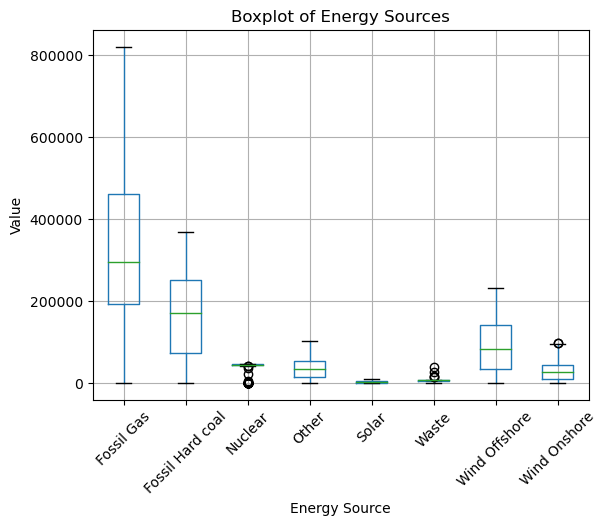

```python
# boxplot: presence of outliers
df_train.boxplot(column=['Fossil Gas', 'Fossil Hard coal', 'Nuclear', 'Other', 'Solar', 'Waste', 'Wind Offshore', 'Wind Onshore'])
plt.xlabel('Energy Source')
plt.ylabel('Value')
plt.title('Boxplot of Energy Sources')
plt.xticks(rotation=45)
plt.show()
```

Furthermore, to make the outliers even more concrete and visual, a list of all the outliers per energy source is given, and the total count of all existing outliers is given.

Next, A threshold of 30% above the maximum acceptable value or 30 % below the minimum acceptable value (so a value that is not considered to be an outlier) is created. If the outlier is above or below this, it will be considered as an outlier which has a significant effect on the dataset. These datapoints will be deleted from the dataset and saved in the dataset df_train_no_outliers.

```python
# outliers detection

outliers_df = pd.DataFrame(columns=['Energy Type', 'Outlier Value'])
outlier_count = {}

# define a function to detect outliers using the IQR method
def detect_outliers(series):
    Q1 = series.quantile(0.25)
    Q3 = series.quantile(0.75)
    IQR = Q3 - Q1
    lower_bound = Q1 - 1.5 * IQR
    upper_bound = Q3 + 1.5 * IQR
    outliers = series[(series < lower_bound) | (series > upper_bound)]
    percentage_above_upper_bound = ((outliers - upper_bound) / upper_bound) * 100
    percentage_below_lower_bound = ((lower_bound - outliers) / lower_bound) * 100
    return outliers, percentage_above_upper_bound, percentage_below_lower_bound

# List to store values exceeding upper bound by 30% or falling below lower bound by 30%
values_to_delete = []

# iterate over each energy type column
for energy_type in ['Fossil Gas', 'Fossil Hard coal', 'Nuclear', 'Other', 'Solar', 'Waste', 'Wind Offshore', 'Wind Onshore']:
    # detect outliers in the current energy type column
    outliers, pct_above_upper, pct_below_lower = detect_outliers(df_train[energy_type])

    # store values exceeding 30% above upper bound or 30% below lower bound
    values_to_delete.extend(outliers[(pct_above_upper > 30) | (pct_below_lower > 30)].tolist())

    # filter outliers exceeding 30% above upper bound or 30% below lower bound
    outliers_filtered = outliers[(pct_above_upper > 30) | (pct_below_lower > 30)]

    # add filtered outliers to the outliers DataFrame
    outliers_df = pd.concat([outliers_df, pd.DataFrame({'Energy Type': [energy_type] * len(outliers_filtered),
                                                        'Outlier Value': outliers_filtered})])

    # count outliers for each type of energy
    outlier_count[energy_type] = len(outliers_filtered)

# reset index of outliers_df
outliers_df.reset_index(drop=True, inplace=True)

# view
#print("Outliers in the dataset:\n\n", outliers_df)
print("\n\nOutliers count:\n\n", outlier_count)

# Values exceeding upper bound by 30% or falling below lower bound by 30%
#print("\n\nValues exceeding upper bound by 30% or falling below lower bound by 30%:\n\n", values_to_delete)

# Count of values deleted
print("\n\nCount of values deleted:", len(values_to_delete))
```

```
Outliers count:

 {'Fossil Gas': 0, 'Fossil Hard coal': 0, 'Nuclear': 39, 'Other': 0, 'Solar': 0, 'Waste': 5, 'Wind Offshore': 0, 'Wind Onshore': 2}


Count of values deleted: 46
```

```python
# Create a copy of df_train to preserve the original data
df_train_no_outliers = df_train.copy()

# Iterate over each value to delete
for value in values_to_delete:
    # Iterate over each energy type column
    for energy_type in ['Fossil Gas', 'Fossil Hard coal', 'Nuclear', 'Other', 'Solar', 'Waste', 'Wind Offshore', 'Wind Onshore']:
        # If the value exists in the corresponding column, delete it
        if value in df_train_no_outliers[energy_type].values:
            df_train_no_outliers = df_train_no_outliers[df_train_no_outliers[energy_type] != value]

# Reset index of df_train_no_outliers
df_train_no_outliers.reset_index(drop=True, inplace=True)

# View
#print("DataFrame df_train_no_outliers after removing outliers:\n", df_train_no_outliers)
```

The conclusion for this step is that:

- Missing Values: The dataset is now free from columns with entirely missing data, ensuring that the model trains on features with valid data points.
- Negative and Incorrect Values: Correction of implausible values ensures the model's input reflects realistic scenarios.
- Outliers: The visual inspection through boxplots aids in identifying and subsequently addressing outliers, leading to a more robust prediction model.

This approach of meticulous data cleaning and preprocessing forms the foundation for accurate and reliable predictive modelling, enhancing the overall data quality and ensuring the integrity of the analysis.

From this point onwards, model A and model B will be treated separately

### (A2.1 Feature creation date training set)

This step is already taken at this point in the code because of simplicity of calculation. Motivation of this features is done at part A2.1.

At the moment, the row index is set as the DateTime. However, the DateTime is split up resulting in two separate columns for month and day. Next, the DateTime column is dropped from the dataset such that the data is not time-dependent any more.

```python
# data reduction (training)

# change into daily frequency and splitting of DateTime
df_train_index_red = df_train_no_outliers.copy()
df_train_index_red.set_index('DateTime', inplace=True)
df_train_index_red['Month'] = df_train_index_red.index.month
df_train_index_red['Day'] = df_train_index_red.index.day
df_train_index_red.reset_index(inplace=True)
df_train_without_date = df_train_index_red.drop(columns=['DateTime'])
#df_train_without_date
```

At last, the preprocessing steps are repeated for the test set, ensuring consistency and comparability between the training and testing phases of the modelling process.

```python
# data cleaning (test)

# drop columns with NaN values
df_test = df_test.dropna(axis=1, how='all')

# drop columns with all float64 values equal to zero
df_test = df_test.loc[:, ~(df_test.dtypes == 'float64') | (df_test != 0).any()]

# drop columns containing both zeros and NaN values
df_test = df_test.loc[:, ~(df_test.apply(lambda col: all(val == 0 or pd.isna(val) for val in col)))]

# values >= 0 --> This test should be lead in data cleaning
energy_sources_data_test = df_test.iloc[:,1:]
if (energy_sources_data_test < 0).any().any():
    rows_with_negative_values_test = energy_sources_data_test[(energy_sources_data_test < 0).any(axis=1)]
    print(rows_with_negative_values_test)
else:
    print("All the values are compliant.")
```

```
All the values are compliant.
```

```python
# check for NA values in the other columns
if (energy_sources_data_test == "").any().any() or (energy_sources_data_test == -1).any().any():
    columns_with_na_test = energy_sources_data_test.columns[(energy_sources_data_test == "").any() | (energy_sources_data_test == -1).any()].tolist()
    print(f"There are missing values in the following columns: {columns_with_na_test}")
else:
    print("There are no missing values in any column.")
```

```
There are no missing values in any column.
```

### (A2.1 Feature creation for test set)

```python
# data reduction (test)

# change into daily frequency and splitting of DateTime
df_test_index_red = df_test.copy()
df_test_index_red.set_index('DateTime', inplace=True)
df_test_index_red['Month'] = df_test_index_red.index.month
df_test_index_red['Day'] = df_test_index_red.index.day
df_test_index_red.reset_index(inplace=True)
df_test_without_date = df_test_index_red.drop(columns=['DateTime'])
#df_test_without_date
```

Regarding data reduction, it is important to generate an understanding whether to remove variables due to correlation, namely offshore wind and onshore wind. To accomplish this, a correlation analysis is performed, giving an overview between all given energy sources and their correlations with other sources.

### A1.3: Scaling

For the last step of the data preprocessing, there is looked at the scaling of the data.

Scaling is used for the resulting series. This is done to normalize the time series data to ensure uniform scale across all features, thereby enhancing the model's ability to learn and make accurate predictions. The following steps are taken:

- 1.3.1 Correlation Calculation. After aggregating the data, it's common to examine the relationships between different variables, in this case, between different energy sources. The correlation matrix helps identify which energy sources are positively or negatively correlated with each other. This insight can be valuable for feature selection or understanding the dynamics of the energy system.
- 1.3.2: Normality check. Normalization is a crucial preprocessing step, particularly for machine learning algorithms like neural networks. The Shapiro-Wilk test assesses whether the data follows a normal distribution. This is important because some machine learning algorithms assume normality in the data. The outcome from this step is that the data is not normally distributed.

The Shapiro-Wilk test: A statistical test used to assess whether a given sample of data comes from a normally distributed population. It's particularly useful because many statistical techniques, such as t-tests, ANOVA, and linear regression, rely on the assumption of normality in the data. If this assumption is violated, the results of these analyses may be misleading or inaccurate.

1.3.1. Correlation Calculation

In this section, a correlation analysis among the available variables has been led, in order to understand whether there could be some kind of relationship. As it is possible to see from the results, there could be a linkage between wind onshore and wind offshore, as the computed coefficient assume a value that is close to 1.

```python
# correlation analysis

df_correlation = df_train_without_date.copy()
correlation_matrix = df_correlation.corr()
print(correlation_matrix)
```

```
                  Fossil Gas  Fossil Hard coal   Nuclear     Other     Solar  \
Fossil Gas          1.000000          0.143239  0.106039  0.510724 -0.034906
Fossil Hard coal    0.143239          1.000000  0.169338  0.217184 -0.585138
Nuclear             0.106039          0.169338  1.000000  0.192448 -0.344015
Other               0.510724          0.217184  0.192448  1.000000 -0.206151
Solar              -0.034906         -0.585138 -0.344015 -0.206151  1.000000
Waste              -0.054784          0.221532 -0.179325 -0.095841 -0.029710
Wind Offshore      -0.607096         -0.188952  0.118702 -0.089045 -0.233612
Wind Onshore       -0.642520         -0.184672  0.138485 -0.097539 -0.255363
Month               0.080024          0.057343 -0.031126 -0.215275 -0.175823
Day                 0.112789         -0.038179 -0.013436  0.084395 -0.015855

                     Waste  Wind Offshore  Wind Onshore     Month       Day
Fossil Gas       -0.054784      -0.607096     -0.642520  0.080024  0.112789
Fossil Hard coal  0.221532      -0.188952     -0.184672  0.057343 -0.038179
Nuclear          -0.179325       0.118702      0.138485 -0.031126 -0.013436
Other            -0.095841      -0.089045     -0.097539 -0.215275  0.084395
Solar            -0.029710      -0.233612     -0.255363 -0.175823 -0.015855
Waste             1.000000      -0.044196     -0.058066 -0.245574  0.035773
Wind Offshore    -0.044196       1.000000      0.910559 -0.033037 -0.004256
Wind Onshore     -0.058066       0.910559      1.000000 -0.115052  0.008365
Month            -0.245574      -0.033037     -0.115052  1.000000 -0.004086
Day               0.035773      -0.004256      0.008365 -0.004086  1.000000
```

1.3.2 Normality check

The columns representing anything implying a date or time are dropped. This means that the data that is left is not time-dependent. Hereafter, both training and test data are checked on whether they follow a normal distribution. This seems not to be the case.

```python
# data transformation (training)

# normalisation
data_transf_train = df_train_without_date.copy()
columns_to_drop_train = ["Month", "Day"]
data_transf_train.drop(columns_to_drop_train, axis=1, inplace=True)

# normal distribution
stat_train, p_value_train = shapiro(data_transf_train)
if p_value_train > 0.05:
    print("Data seem to follow a normal distribution")
else:
    print("Data seem not to follow a normal distribution")

data_pp_train = df_train_without_date.copy()
```

```
Data seem not to follow a normal distribution
```

```python
# data transformation (test)

# normalisation
data_transf_test = df_test_without_date.copy()
columns_to_drop_test = ["Month", "Day"]
data_transf_test.drop(columns_to_drop_test, axis=1, inplace=True)

# normal distribution
stat_test, p_value_test = shapiro(data_transf_test)
if p_value_test > 0.05:
    print("Data seem to follow a normal distribution")
else:
    print("Data seem not to follow a normal distribution")

data_pp_test = df_test_without_date.copy()
```

```
Data seem not to follow a normal distribution
```

1.3.3 Data Transformation

Scaling, or normalization, refers to the process of standardizing the range of values of variables. It's a crucial step in data preprocessing, and here's why it's important:

- Equal Weightage: Scaling ensures that all variables contribute equally to the analysis. Without scaling, variables with larger magnitudes might dominate those with smaller magnitudes, leading to biased results.
- Enhanced Interpretability: Scaling makes the interpretation of coefficients or feature importance more straightforward. It allows for a fair comparison of the impact of different features on the model's output.
- Better Performance: Scaled data often leads to better performance of machine learning models. It helps prevent certain algorithms from getting stuck in local optima and improves the overall stability and robustness of the model.

Normally, the normalization step is the last step performed in the pre-processing of the data. For this analysis, the normalization of the data is postponed until after the feature creation. This is done such that all the data is normalized at the same time, instead of first the columns in the dataset and afterwards the features. In a two-step normalization, the available data is examined twice, and normalization is performed based on it each time. This means that feature normalization differs from dataset normalization. This can lead to discrepancies. To prevent this, the entire dataset, including features, is normalized after creating the features.

## A2: Feature creation

In this section of the notebook, we dive into the process of transforming raw data into meaningful features that enhance the predictive power of our models. Effective feature creation is essential for extracting relevant information from the data and capturing complex relationships that can improve model performance.

During feature creation, we engage in various processes aimed at enriching the dataset with informative features. These processes include aggregation, transformation, encoding, and selection. By leveraging domain knowledge and understanding the underlying structure of the data, we can craft features that better represent the underlying patterns and relationships.

To guide our feature creation process, we use visualization techniques to explore the data, identify patterns, and assess the potential utility of different features.

After the feature creation, various selections are implemented in the model, where the optimal combination of features is finally selected to be included. As a result, not all features created below are finally adopted in the model.

### A2.1: 'Part of the date' features

"Part of the date" features has already been included (see A1.2). It has been decided to use day and month as reference variables; year, instead, has not been included since the available data are spread on a relatively short period of time (just one year), so this feature does not seem to be particularely significant. To catch possible seasonal patterns, instead, it has been decided to add a feature representing the season, by mean of a definitio properly built for this purpose.

For the wind onshore, a line chart is developed over the given time in the data (per day), to facilitate a clear image of the energy generated of the variable. This allows to have an immediate understanding of how data are distributed over the period considere: a visual representation can help in raughly recognising potential patterns, that can be later confirmed by the analysis supported by the features created.

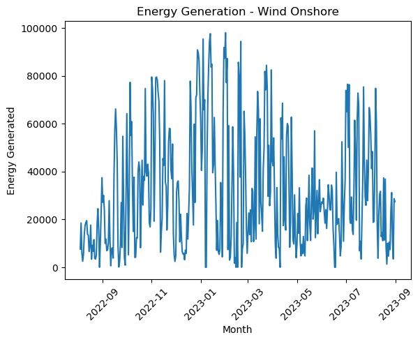

```python
# Chart to show relation of wind onshore against day
data_line = df_train.copy()
columns_1 = ["DateTime","Wind Onshore"]
data_line_1 = data_line[columns_1].copy()

x_line = data_line_1["DateTime"]
y_line = data_line_1["Wind Onshore"]

plt.plot(x_line, y_line)
plt.xlabel('Month')
plt.ylabel('Energy Generated')
plt.title('Energy Generation - Wind Onshore')

plt.xticks(rotation=45)
plt.show()
```

Furthermore, since the wind onshore is expected to have a very similar pattern as wind offshore, a line chart for this energy source is created as well.

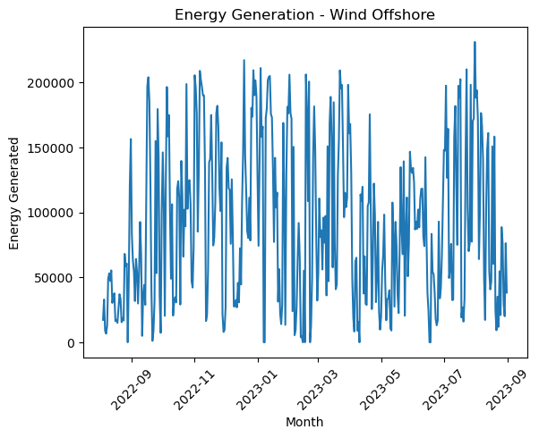

```python
# Chart to understand relationship between wind onshore and wind offshore
data_line = df_train.copy()
columns_2 = ["DateTime","Wind Offshore"]
data_line_1 = data_line[columns_2].copy()

x_line = data_line_1["DateTime"]
y_line = data_line_1["Wind Offshore"]

plt.plot(x_line, y_line)
plt.xlabel('Month')
plt.ylabel('Energy Generated')
plt.title('Energy Generation - Wind Offshore')

plt.xticks(rotation=45)
plt.show()
```

To dive further into the 'part of the date' features for the wind on shore variable, now a line chart is developed for every month in the dataset, to see more elaborated and specific seasonal patterns. This could be interesting since 'part of the date' features are necessary to include in the model.

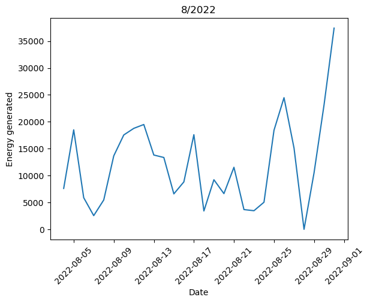

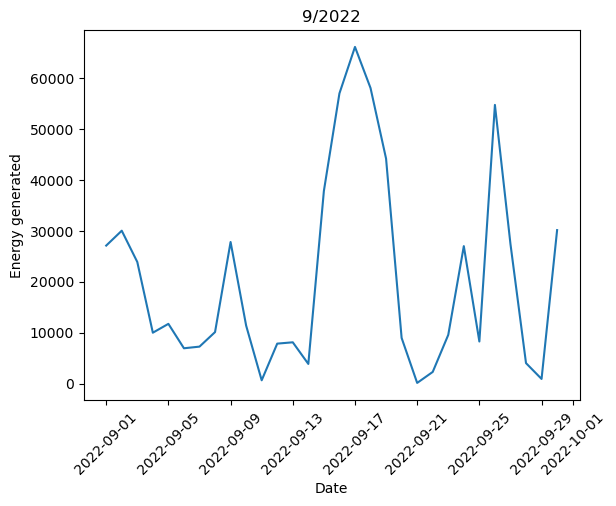

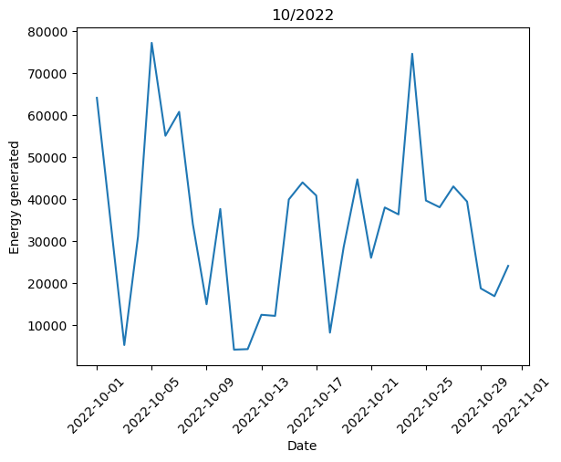

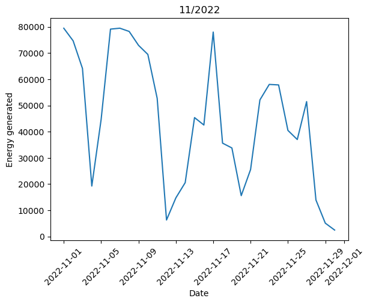

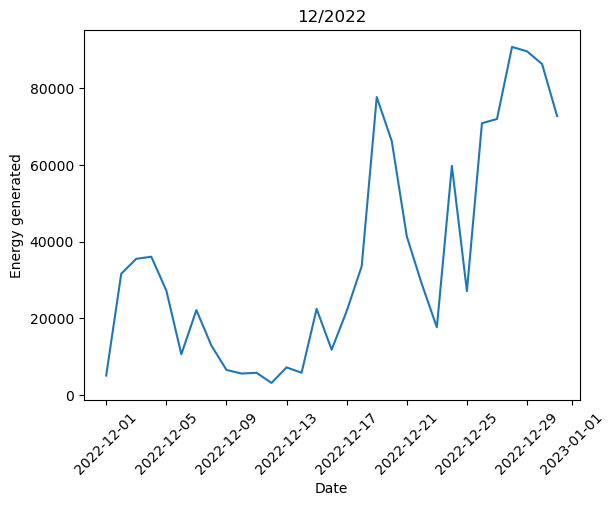

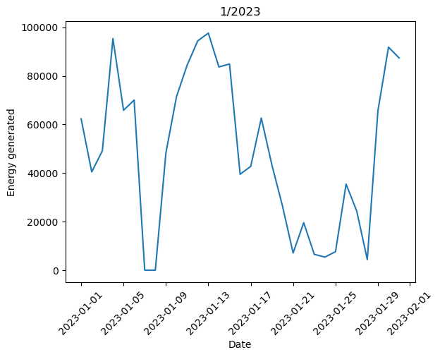

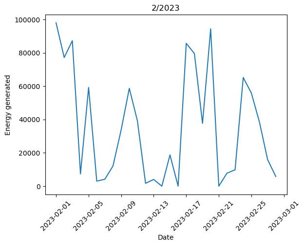

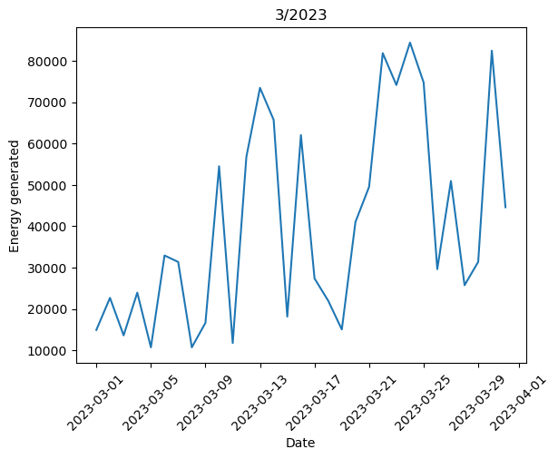

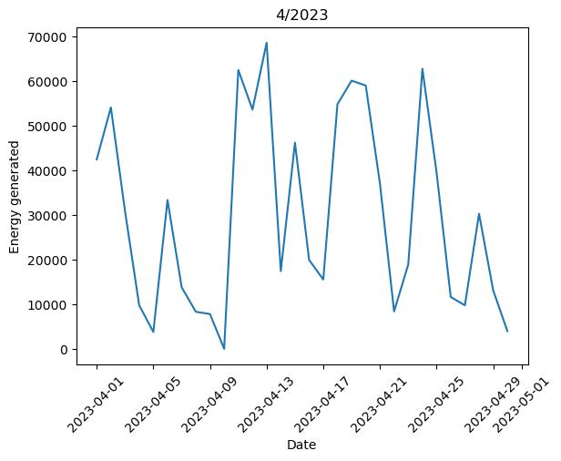

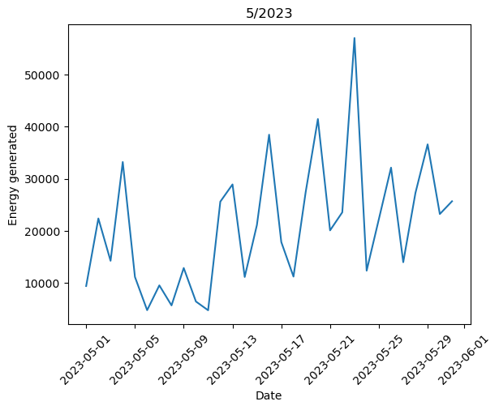

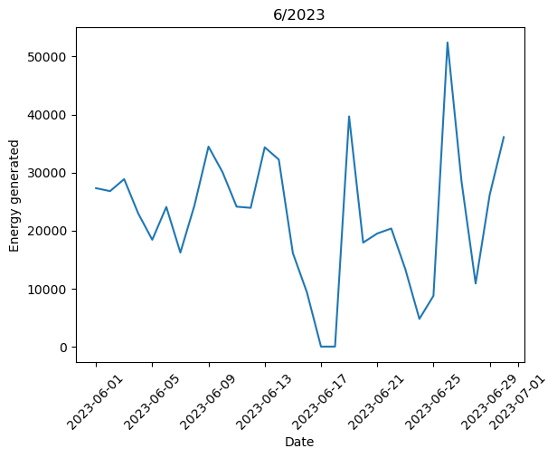

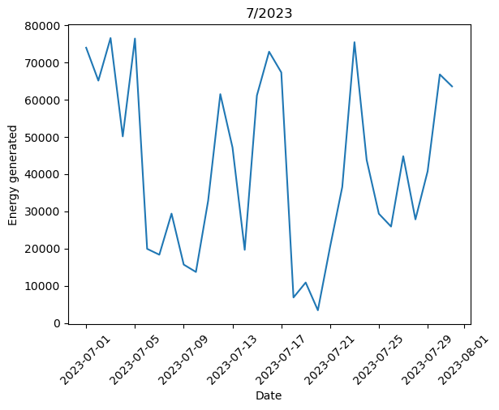

[1 more figures not shown]

```python
# Wind Onshore chart month by month
data_line_2 = data_line[columns_1].copy()
data_line_2['Month'] = data_line_2['DateTime'].dt.month
data_line_2['Year'] = data_line_2['DateTime'].dt.year

monthly_data = data_line_2.groupby([data_line_2['Year'], data_line_2['Month']])

for (year, month), data_month_year in monthly_data:
    plt.figure()
    plt.plot(data_month_year['DateTime'], data_month_year['Wind Onshore'])
    plt.title(f"{month}/{year}")
    plt.xlabel('Date')
    plt.ylabel('Energy generated')
    plt.xticks(rotation=45)
    plt.show()
```

Moreover, a boxplot is created to visualize differences in energy generated of the wind onshore, per day of the week. As visible, for example wednesday tends to have a relatively low amount of energy generated for the wind onshore. This could be useful to use in the model as well.

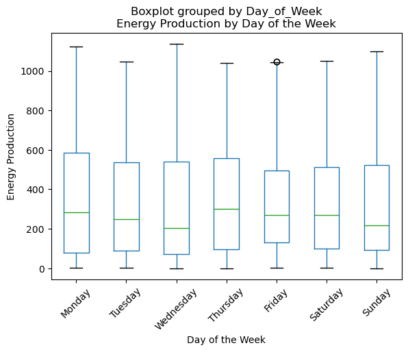

```python
data_pp_2 = df_train_index.copy()
data_pp_2['Day_of_Week'] = data_pp_2.index.day_name()

days_order = ['Monday', 'Tuesday', 'Wednesday', 'Thursday', 'Friday', 'Saturday', 'Sunday']
data_pp_2['Day_of_Week'] = pd.Categorical(data_pp_2['Day_of_Week'], categories=days_order, ordered=True)

# Create boxplot
plt.figure(figsize=(10, 6))
data_pp_2.boxplot(column="Wind Onshore", by='Day_of_Week', grid=False)
plt.title('Energy Production by Day of the Week')
plt.xlabel('Day of the Week')
plt.ylabel('Energy Production')
plt.xticks(rotation=45)
plt.show()
```

```python
# Season (training)

def season_id(num_month):
    seasons = {
        '1': [3, 4, 5], # spring
        '2': [6, 7, 8], # summer
        '3': [9, 10, 11], # fall
        '4': [12, 1, 2] # winter
    }
    for seas, months_in_season in seasons.items():
        if num_month in months_in_season:
            return seas
    return "Error"

data_pp_train['Season'] = data_pp_train['Month'].apply(season_id)
data_pp_train['Season'] = data_pp_train['Season'].astype(int)
#data_pp_train
```

```python
# Season (test)

data_pp_test['Season'] = data_pp_test['Month'].apply(season_id)
data_pp_test['Season'] = data_pp_test['Season'].astype(int)
#data_pp_test
```

### A2.2: Features based on the frequency distribution of the series

In the process of feature creation, one crucial aspect involves deriving features based on the frequency distribution of the series. This includes computing statistics such as mean, median, mode, standard deviation, and other measures that summarize the distribution of the data.

By analyzing the frequency distribution of the series, it is possible to gain insights into its central tendency, variability, and shape, which can inform the creation of informative features. These features not only capture important characteristics of the data but also provide valuable information for predictive modeling tasks.

As a good starting point, some basic explorative boxplots and bar charts are created, based on the frequency distribution of the series, to illustrate potential interesting directions to dive further into.

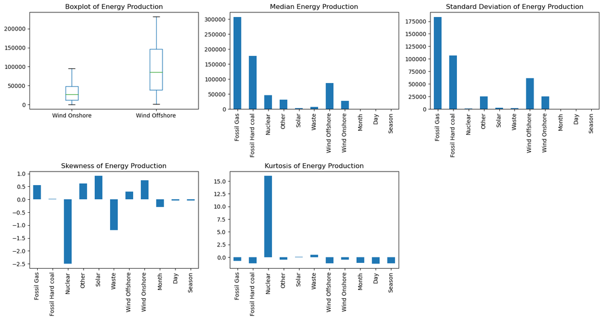

```python
# Calculate statistics for each energy source
data_pp_3 = data_pp_train.copy()

mean_values = data_pp_3.mean()
median_values = data_pp_3.median()
std_values = data_pp_3.std()
skewness_values = data_pp_3.skew()
kurtosis_values = data_pp_3.kurt()

# Create boxplots
plt.figure(figsize=(15, 8))

# Boxplot for Wind Onshore Energy Production
plt.subplot(2, 3, 1)
data_pp_3.boxplot(column=["Wind Onshore", "Wind Offshore"], grid=False)
plt.title('Boxplot of Energy Production')

# Barchart for median values
plt.subplot(2, 3, 2)
data_pp_3.median().plot(column="Wind Onshore",kind='bar', rot=0)
plt.title('Median Energy Production')
plt.xticks(rotation=90)

# Barchart for standard deviation values
plt.subplot(2, 3, 3)
data_pp_3.std().plot(column="Wind Onshore",kind='bar', rot=0)
plt.title('Standard Deviation of Energy Production')
plt.xticks(rotation=90)

# Barchart for skewness values
plt.subplot(2, 3, 4)
data_pp_3.skew().plot(column="Wind Onshore",kind='bar', rot=0)
plt.title('Skewness of Energy Production')
plt.xticks(rotation=90)

# Barchart for kurtosis values
plt.subplot(2, 3, 5)
data_pp_3.kurt().plot(column="Wind Onshore",kind='bar', rot=0)
plt.title('Kurtosis of Energy Production')
plt.xticks(rotation=90)

plt.tight_layout()
plt.show()
```

The cell below is dedicated to the creation of features based on the frequency distribution of the wind energy generation series. Through the computation of statistical measures such as mean, difference, and range across designated time intervals, the goal is to encapsulate key attributes of the data that enhance its predictive capabilities.

Below outlines the feature creation process:

1. Selection of Relevant Features: Relevant features are chosen from the preprocessed dataset, focusing on variables concerning onshore wind energy generation, encompassing both "Wind Offshore" and "Wind Onshore".
2. Calculation of Statistical Measures: Various statistical measures are computed based on the frequency distribution of the "Wind Onshore" energy generation series. These measures consist of:
- Weekly Mean: Average energy generation over the preceding 7 days, providing insight into typical energy output.
- Delta: Discrepancy between the energy generation value of the day before the one considered and the weekly mean, highlighting deviations from the usual trend.
- Weekly Range: Variation between the maximum and minimum energy generation values over the past 7 days, indicating fluctuation in energy output.
- Weekly Mean Offshore: Mean energy generation of offshore wind farms over the previous 7 days, offering supplementary context to onshore wind energy generation.
1. Application of Rolling Windows: Rolling windows are employed to compute these features, facilitating the calculation of statistics over specific time intervals. By utilizing rolling windows with a size of 7 days, weekly trends and patterns in the data are captured.

Through the creation of these features, the objective is to augment the dataset with meaningful information reflecting the underlying dynamics of wind energy generation. These features are crucial inputs for training and evaluating machine learning models, ultimately enhancing their predictive performance.

```python
# features from frequency distribution
data_fc_train = data_pp_train[["Wind Offshore", "Wind Onshore", "Day", "Month", "Season"]].copy()
energy_value_train = data_fc_train["Wind Onshore"]
energy_shift_train = data_fc_train["Wind Onshore"].shift(1)

# mean of the previous 7 days
window_1_train = energy_shift_train.rolling(window = 7).mean()
data_fc_train["Weekly Mean"] = window_1_train

# difference between value and weekly mean
data_fc_train["Delta"] = (energy_shift_train - window_1_train)

# weekly range
window_2_train = energy_shift_train.rolling(window = 7).max()
window_3_train = energy_shift_train.rolling(window = 7).min()
data_fc_train["Weekly Range"] = (window_2_train - window_3_train)

# wind offshore weekly mean
wind_offshore_train = data_fc_train["Wind Offshore"].shift(1)
window_wind_offshore_train = wind_offshore_train.rolling(window = 7).mean()
data_fc_train["Weekly Mean Offshore"] = window_wind_offshore_train

#data_fc_train.head()
```

The expanding window for the training data is outlined below, offering insights into how the statistical properties of onshore wind energy production evolve as more historical data is included.

The expanding window commences from the earliest available data point and progressively widens to encompass additional historical observations. Within this expanding window, three key statistical measures are computed:

- Minimum: The minimum energy generation value observed within the expanding window, indicating the lowest recorded level of energy generation.
- Mean: The mean energy generation value observed within the expanding window, providing insight into the average energy output over time.
- Maximum: The maximum energy generation value observed within the expanding window, representing the peak level of energy generation.

```python
# expanding window (training)

def create_expanding_window(df):
    energy = df["Wind Onshore"]
    window = energy.shift(1).expanding()
    df_new = pd.concat([window.min(), window.mean(), window.max()], axis=1)
    df_new.columns = ['exp_min', 'exp_mean', 'exp_max']
    df_new = df_new.dropna()
    return df_new

df_exp_train = create_expanding_window(data_fc_train)
data_fc_train = pd.concat([data_fc_train, df_exp_train], axis=1)
#data_fc_train
```

### A2.3: Features involving more advanced response features

In this section, the exploration focuses on the creation of features derived from advanced response features, emphasizing change points or regression models.

Change points represent significant shifts or transitions in the underlying patterns of the time series data. The process of evaluating change points and integrating them into the dataset is outlined as follows:

- Evaluation of Change Points: Change points are computed on the "Wind Onshore" energy generation series to pinpoint instances where notable deviations or transitions occur. However, to circumvent overlapping between input and output data, the weekly mean is chosen instead.
- Calculation of Threshold: A threshold is determined to identify change points, evaluated as the average value of standard deviation within a specified window size. This threshold acts as a benchmark for distinguishing between normal fluctuations and significant changes in energy generation. It is computed by means of a definition.
- Addition of Threshold Column: A new column labeled "threshold_WM" is introduced to the dataset, indicating whether the weekly mean energy generation surpasses the calculated threshold. This binary feature serves as a response variable, signaling the occurrence of noteworthy deviations in energy generation.

Through the inclusion of features derived from change points, the aim is to capture crucial transitions and fluctuations in wind energy generation that could impact predictive modeling tasks. These features offer valuable insights into the dynamic nature of the energy landscape, potentially augmenting the predictive capability of machine learning models. Let's proceed with the creation and integration of these advanced response features to further enhance the dataset for modeling endeavors.

```python
# features from change points (training)

# evaluation of the average value of standard deviation
def calculate_threshold(data, window_size):
    std_devs = []
    for i in range(len(data) - window_size):
        window = data[i:i+window_size]
        std_dev = np.std(window)
        std_devs.append(std_dev)
    return np.mean(std_devs) ## we can keep this part to compute the threshold from the training data

def add_threshold_column(df, threshold):
    df['threshold_WM'] = 0
    df.loc[df["Weekly Mean"] > threshold, 'threshold_WM'] = 1
    return df

threshold_std_train = calculate_threshold(data_fc_train["Weekly Mean"], 14)
data_fc_train = add_threshold_column(data_fc_train, threshold_std_train)

data_fc_train = data_fc_train.dropna()
#data_fc_train
```

[output not shown]

327 rows × 13 columns

To proceed, exploration continues with the creation of features derived from linear regression analysis.

Linear regression allows modeling the relationship between the weekly mean energy generation (independent variable) and the corresponding weekly mean offshore wind energy generation (dependent variable). These reference variables has been chosen as it is known that wind onshore and wind offshore are related to each other, even if this does not guarantee that the relationship between the mean values is equivalent. Below outlines the process of performing linear regression and integrating the residuals as features in the dataset.

- Linear Regression Modeling: Linear regression is employed to model the relationship between the weekly mean energy generation and the weekly mean offshore wind energy generation. The weekly mean energy generation serves as the independent variable (X), while the weekly mean offshore wind energy generation serves as the dependent variable (Y).
- Calculation of Residuals: Following the fitting of the linear regression model to the training data, residuals are computed by subtracting the predicted values of the dependent variable from the actual values. Residuals reflect the disparities between observed and predicted values, offering insights into the model's performance and the presence of unexplained variability in the data.
- Integration of Residuals: A new column labeled "Residuals" is appended to the dataset, incorporating the calculated residuals as features. These residuals capture the deviations between actual and predicted offshore wind energy generation values, potentially revealing patterns and trends not captured by the linear regression model.

Through the creation of features from regression analysis, the objective is to gather additional insights into the relationship between weekly mean energy generation and offshore wind energy generation. These features shed light on the predictive performance of the linear regression model and may unveil intricate relationships that enhance the efficacy of predictive modeling tasks. Let's proceed with the creation and integration of these regression-based features to further enrich the dataset for modeling endeavors.

```python
# features from regression (training)

x_regression_train = data_fc_train["Weekly Mean"].values.reshape(-1, 1)
y_regression_train = data_fc_train["Weekly Mean Offshore"].values

regression_model_train = LinearRegression()
regression_model_train.fit(x_regression_train, y_regression_train)
residuals_train = y_regression_train - regression_model_train.predict(x_regression_train)

data_fc_train.loc[:, "Residuals"] = residuals_train
data_fc_train
```

|  | Wind Offshore | Wind Onshore | Day | Month | Season | Weekly Mean | Delta | Weekly Range | Weekly Mean Offshore | exp_min | exp_mean | exp_max | threshold_WM | Residuals |
| --- | --- | --- | --- | --- | --- | --- | --- | --- | --- | --- | --- | --- | --- | --- |
| 7 | 47299.0 | 18774.0 | 11 | 8 | 2 | 10167.714286 | 7377.285714 | 15949.0 | 25826.857143 | 2544.0 | 10167.714286 | 18493.0 | 1 | -21647.161950 |
| 8 | 55377.0 | 19489.0 | 12 | 8 | 2 | 11763.571429 | 7010.428571 | 16230.0 | 30113.714286 | 2544.0 | 11243.500000 | 18774.0 | 1 | -20790.437129 |
| 9 | 30334.0 | 13816.0 | 13 | 8 | 2 | 11905.857143 | 7583.142857 | 16945.0 | 33318.428571 | 2544.0 | 12159.666667 | 19489.0 | 1 | -17891.551488 |
| 10 | 35393.0 | 13356.0 | 14 | 8 | 2 | 13040.428571 | 775.571429 | 16945.0 | 36383.857143 | 2544.0 | 12325.300000 | 19489.0 | 1 | -17264.768598 |
| 11 | 37761.0 | 6591.0 | 15 | 8 | 2 | 14585.000000 | -1229.000000 | 14034.0 | 40496.000000 | 2544.0 | 12419.000000 | 19489.0 | 1 | -16472.524645 |
| ... | ... | ... | ... | ... | ... | ... | ... | ... | ... | ... | ... | ... | ... | ... |
| 329 | 76510.0 | 31206.0 | 27 | 8 | 2 | 9403.857143 | 13732.142857 | 21816.0 | 35093.285714 | 117.0 | 32969.568389 | 95362.0 | 1 | -10738.900282 |
| 330 | 29281.0 | 10998.0 | 28 | 8 | 2 | 12614.285714 | 18591.714286 | 29886.0 | 42444.000000 | 117.0 | 32964.224242 | 95362.0 | 1 | -10288.675090 |
| 331 | 20078.0 | 3457.0 | 29 | 8 | 2 | 13996.857143 | -2998.857143 | 26530.0 | 45299.857143 | 117.0 | 32897.861027 | 95362.0 | 1 | -10404.514358 |
| 332 | 76323.0 | 28682.0 | 30 | 8 | 2 | 13056.571429 | -9599.571429 | 27749.0 | 43157.000000 | 117.0 | 32809.183735 | 95362.0 | 1 | -10526.323167 |
| 333 | 38272.0 | 27428.0 | 31 | 8 | 2 | 16486.000000 | 12196.000000 | 27749.0 | 52360.285714 | 117.0 | 32796.789790 | 95362.0 | 1 | -8694.244732 |

327 rows × 14 columns

Now, for the test data, the same codes for these features have to be performed below.

```python
# features from frequency distribution
data_fc_test = data_pp_test[["Wind Offshore", "Wind Onshore", "Day", "Month", "Season"]].copy()
energy_value_test = data_fc_test["Wind Onshore"]
energy_shift_test = data_fc_test["Wind Onshore"].shift(1)

# mean of the previous 7 days
window_1_test = energy_shift_test.rolling(window = 7).mean()
data_fc_test["Weekly Mean"] = window_1_test

# difference between value and weekly mean
data_fc_test["Delta"] = (energy_shift_test - window_1_test)

# weekly range
window_2_test = energy_shift_test.rolling(window = 7).max()
window_3_test = energy_shift_test.rolling(window = 7).min()
data_fc_test["Weekly Range"] = (window_2_test - window_3_test)

# wind offshore weekly mean
wind_offshore_test = data_fc_test["Wind Offshore"].shift(1)
window_wind_offshore_test = wind_offshore_test.rolling(window = 7).mean()
data_fc_test["Weekly Mean Offshore"] = window_wind_offshore_test

#data_fc_test.head()
```

```python
df_exp_test = create_expanding_window(data_fc_test)
data_fc_test = pd.concat([data_fc_test, df_exp_test], axis=1)
#data_fc_test
```

```python
# features from change points (test)
data_fc_test = add_threshold_column(data_fc_test, threshold_std_train)
data_fc_test = data_fc_test.dropna()
#data_fc_test
```

```python
# features from regression (test)

x_regression_test = data_fc_test["Weekly Mean"].values.reshape(-1, 1)
y_regression_test = data_fc_test["Weekly Mean Offshore"].values

regression_model_test = LinearRegression()
regression_model_test.fit(x_regression_test, y_regression_test)
residuals_test = y_regression_test - regression_model_test.predict(x_regression_test)

data_fc_test.loc[:, "Residuals"] = residuals_test

#data_fc_test
```

### A1.3 Normalizatoin of the data (step 1.3.3)

After the creation of the features, the data is normalized as explained in section A1.3. This happens via the Standard scaler.

- First the test and the train data are loaded for the scaler
- Next the Standard Scaler is initialized
- At last, both the train and the test data are normalized using this scaler

```python
from sklearn.preprocessing import StandardScaler

# data
data_nn_train = data_fc_train.copy()
data_nn_test = data_fc_test.copy()

# data normalisation
scaler = StandardScaler()
data_nn_train_norm = pd.DataFrame(scaler.fit_transform(data_nn_train), columns=data_nn_train.columns)
data_nn_test_norm = pd.DataFrame(scaler.fit_transform(data_nn_test), columns=data_nn_test.columns)
```

## A3 Model preparations

### A3.1 Utilization of Separate Test Data for Testing

Following best practices for model evaluation and validation, the provided separate test data is exclusively used for testing purposes. This guarantees that the model's performance is assessed on unseen data, offering a robust evaluation of its generalization capabilities.

Definition of Training and Test Variables:  
The input variables (features, x) and target variables (labels, y) for both the training and test datasets are defined and split. For the neural network models, various subsets of the features that are introduced above have been applied in the code below, whereafter the following selection has resulted in the best subset for predicting the onshore wind energy generation. These features include "Day", "Month", "Weekly Mean", "Delta", "exp_mean", "Weekly Mean Offshore", "Season", "threshold_WM", and "Residuals".

The selected features are also chosen based on their potential relevance to the prediction task and their availability in both the training and test datasets. By including features such as "Weekly Mean", "Weekly Mean Offshore", and "Residuals", we aim to capture temporal patterns, relationships with offshore wind energy generation, and deviations from expected values that may impact onshore wind energy generation.

The next cell represents an important part of the experimental setup that characterises this type of analysis, according to which:

- training data is used to build the model;
- validation data is used to find the best parameters of the prediction model;
- test data is used to evaluate the model.

In this model, as stated, training and test sets are already separated. The validation set, instead, is evaluated during the K-fold cross-validation performed in the model.

```python
# definition of training and test variables
x_nn_train = data_nn_train_norm[["Day", "Month", "Weekly Mean", "Delta", "exp_mean", "Weekly Mean Offshore", "Season", "threshold_WM", "Residuals"]]
y_nn_train = data_nn_train_norm[["Wind Onshore"]]
x_nn_test = data_nn_test_norm[["Day", "Month", "Weekly Mean","Delta" , "exp_mean", "Weekly Mean Offshore","Season", "threshold_WM", "Residuals"]]
y_nn_test = data_nn_test_norm[["Wind Onshore"]]
```

### A3.2 A validation strategy is used.

A validation strategy is used to maintain the temporal order of the data and mirror real-world deployment scenarios. This method guarantees that the model undergoes training and validation using historical data slices. For this cross-validation (KFold) with a fold size of 5 is used (n_splits=5). Reasons to choose cross-validation as a validation method are:

- Reduces Variability in Performance Estimates: Cross-validation provides multiple estimates of model performance by averaging over multiple folds. This helps in obtaining a more stable and reliable estimate of the model's generalization performance, reducing the variability that may arise from using a single train-test split.
- Assists in Hyperparameter Tuning: Cross-validation is particularly useful for hyperparameter tuning. By evaluating the model on multiple folds with different hyperparameter configurations, it provides insights into how the model performs across various parameter settings, aiding in the selection of optimal hyperparameters.

This validation strategy can be seen in the created model, which is showed in A4.

### A3.3: Experimental setup

[figure not shown]

## A4 Model creation

### A4.1 The machine learning technique used is suitable for regression problems.¶

Neural Networks for Regression: The use of a neural network, constructed and trained to predict continuous output values, is inherently suitable for regression problems. This suitability is due to the network's ability to learn complex, non-linear relationships from the input features to the output through the optimization of weights and biases. In general, this choice allows to compare the results deriving from the application of a simple multilayer perceptron (model A) and a recurrent neural network (model B).

### A4.2 Implementation of the model is correct, including the correct selection of hyperparameters.

- Model Architecture: The model_creation function correctly defines a neural network architecture for regression. It includes a dynamic number of hidden layers and neurons, a choice of activation function, and a single output neuron for predicting a continuous value, which is typical for regression tasks.
- Hyperparameter Configuration: The hyperparameters such as the number of hidden layers (num_hidden_layers), number of neurons in each layer (hl_neurons), learning rate (learning_rate_nn), and activation function (activation_function) are appropriately set for initial experimentation. Additionally, training parameters like batch_size and epochs are specified, influencing the learning process's efficiency and effectiveness.
1. Number of Hidden Layers: : Choosing a moderate number of hidden layers balances complexity and the model's ability to learn intricate patterns. Starting with one layer and increasing gradually if needed is a common initial experimentation approach. This method allows exploration without overwhelming complexity.
2. Number of Neurons in Each Layer: The number of neurons per layer is tailored to the problem's complexity and dataset size. For initial exploration, opting for a moderate number of neurons achieves a balance between model complexity and performance.
3. Learning Rate: Selecting a moderate learning rate ensures stable training convergence without compromising speed. This promotes smoother experimentation and model optimization.
4. Activation Function: There are different possible activation functions which embrace the effectiveness of a model. They can have a different proficiency in learning complex nonlinear relationships and therefore a different efficacy in providing a correct prediction.
5. Batch size and Epoches: Choosing moderate batch sizes and a reasonable number of epochs balances how quickly the model converges and how well it generalizes. This method fits well for initial experimentation, taking into account the dataset's size and the computational resources available.

In general, the set of values assign to each hyperparameter to perform the Grid Search has been decided considering:

- the computational power available to test the model in a reasonable amount of time;
- the will of inspecting values that are significantly different from one another (for example, the number of neurons: we pass from 32 to 128).

### A4.3 Performs hyperparameter optimization correctly.

- Grid Search CV: The use of GridSearchCV with a KerasRegressor wrapper illustrates a systematic approach to hyperparameter optimization. It has been chosen since it is known as a simple but solid and well-performing method to optimize the parameters of a model. By exploring a predefined grid of hyperparameter values, the model can identify the combination that yields the best performance, measured in terms of the negative mean squared error (neg_mean_squared_error), which is a standard loss function for regression. The operations lead through the Grid Seach could be implemented in the model in the for cycle related to the k-fold cross validation: this could have helped in reaching a more optimized model. Anyway, it represents a computationally expensive choice, therefore it has been decided to perform the optimization of the parameters before.
- Cross-Validation: Implementing cross-validation (5 folds) ensures that the model's performance is not overly dependent on a particular subset of the data for training, thus providing a more generalized evaluation across different data segments.

The operations lead through the Grid Seach could be implemented in the model in the for cycle related to the k-fold cross validation: this could have helped in reaching a more optimized model. Anyway, it represents a computationally expensive choice, therefore we decided to perform the optimization of the parameters before. We chose GridSearch because it is known as a simple but solid and well-performing method to optimize the parameters of a model.

```python
from scikeras.wrappers import KerasRegressor

# Model creation

# Define the number of folds for cross-validation
num_folds = 5

# Initialize KFold
kf = KFold(n_splits=num_folds)

# Define the model creation function
def model_creation(num_hidden_layers, hl_neurons, learning_rate_nn, activation_function, input_shape):
    model = Sequential()
    model.add(Input(shape=input_shape))  # Adjust the input shape according to your data
    for _ in range(num_hidden_layers):
        model.add(Dense(hl_neurons, activation=activation_function))
    model.add(Dense(1))
    optimizer = Adam(learning_rate=learning_rate_nn)
    model.compile(loss='mean_squared_error', optimizer=optimizer, metrics=['mae', 'mse'])
    return model
```

```python
# Initialize KerasRegressor with model_creation function
input_shape = (len(x_nn_train.columns),)
model = KerasRegressor(model=model_creation, num_hidden_layers=2, hl_neurons=16, learning_rate_nn=0.001, activation_function="relu", batch_size=16, epochs=10, verbose=1, input_shape=input_shape)

# Parameters for grid search
param_grid = {
    'num_hidden_layers': [2, 3],
    'hl_neurons': [32, 64, 128],
    'learning_rate_nn': [0.001, 0.01],
    'activation_function': ['relu', 'tanh'],
    'batch_size': [16, 32],
    'epochs': [10, 20]  # Add epochs to the parameter grid
}

# Perform grid search
grid = GridSearchCV(estimator=model, param_grid=param_grid, n_jobs=1, cv=5, verbose=1, scoring='neg_mean_squared_error')
grid_result = grid.fit(x_nn_train, y_nn_train)

# Summarize results
print("\nBest MSE of: %f using %s" % (-grid_result.best_score_, grid_result.best_params_))

# Load the best model from grid search
best_model = grid_result.best_estimator_

# Perform cross-validation
mse_scores = []
mae_scores = []
r2_scores = []

for train_index, val_index in kf.split(x_nn_train):
    x_train_fold, x_val_fold = x_nn_train.iloc[train_index], x_nn_train.iloc[val_index]
    y_train_fold, y_val_fold = y_nn_train.iloc[train_index], y_nn_train.iloc[val_index]

    # Train the best model on this fold
    best_model.fit(x_train_fold, y_train_fold)

    # Predict on the validation fold
    y_pred = best_model.predict(x_val_fold)

    # Calculate evaluation metrics for this fold
    mse_fold = mean_squared_error(y_val_fold, y_pred)
    mae_fold = np.mean(np.abs(y_pred - y_val_fold))
    r2_fold = r2_score(y_val_fold, y_pred)

    # Store scores for this fold
    mse_scores.append(mse_fold)
    mae_scores.append(mae_fold)
    r2_scores.append(r2_fold)

# Calculate average scores across all folds
avg_mse = np.mean(mse_scores)
avg_mae = np.mean(mae_scores)
avg_r2 = np.mean(r2_scores)

# Print average scores
print("\nAverage MSE across all folds:", avg_mse)
print("Average MAE across all folds:", avg_mae)
print("Average R^2 across all folds:", avg_r2)

# Now, we use the best model to predict on the test set
y_pred_test = best_model.predict(x_nn_test)
```

```
Fitting 5 folds for each of 96 candidates, totalling 480 fits

Best MSE of: 0.712945 using {'activation_function': 'tanh', 'batch_size': 16, 'epochs': 10, 'hl_neurons': 32, 'learning_rate_nn': 0.001, 'num_hidden_layers': 3}

Average MSE across all folds: 0.7505436808063564
Average MAE across all folds: 0.7074430631838693
Average R^2 across all folds: 0.12589045236105978
```

```python
# Calculate evaluation metrics on the test set
mse_test = mean_squared_error(y_nn_test, y_pred_test)
mae_test = np.mean(np.abs(y_pred_test - y_nn_test))
r2_test = r2_score(y_nn_test, y_pred_test)

# Print evaluation metrics on the test set
print("\nTest MSE:", mse_test)
print("Test MAE:", mae_test)
print("Test R^2:", r2_test)
```

```
Test MSE: 0.6429048693956053
Test MAE: 0.6467730542909459
Test R^2: 0.3570951306043947
```

## A5 Model evaluation

The performance of the model is evaluated using commonly used metrics for regression tasks, namely Mean Squared Error (MSE), Mean Absolute Error (MAE) and R-squared (R2) score.

- Mean Squared Error (MSE): MSE is calculated using the mean_squared_error function from Scikit-learn, which compares the predicted values (y_ts_pred) with the actual values (y_ts_test) in the test dataset. MSE measures the average squared difference between the predicted and actual values, providing a measure of the model's accuracy. Lower MSE values indicate better model performance.
- Mean Absolute Error (MAE) metric is commonly used to evaluate the accuracy of regression models. It measures the average absolute difference between the predicted values (y_ts_pred) and the actual values (y_ts_test).
- R-squared (R2) Score: R2 score is calculated using the r2_score function from Scikit-learn. R2 score represents the proportion of the variance in the dependent variable (target) that is predictable from the independent variables (features). It ranges from 0 to 1, where 1 indicates a perfect fit and 0 indicates no better prediction than simply predicting the mean of the target values.

These performance metrics provide valuable insights into how well the model generalizes to unseen data and how much of the variance in the target variable is explained by the model's predictions. By calculating both MSE, MAE and R2 score, the code ensures a comprehensive evaluation of the model's performance on the test dataset.

#### Inverse scaling

The following code gives the post-process actions for the predictions made by a regression model trained on normalized data. It performs the following key steps:

- Inverse Transformation: Using the inverse of the normalization technique applied during training, the predictions and features are converted back to their original scale. This allows for the interpretation of the model's output in a real-world context. In order to do so, we put the predicted values in the dataframe containing test data (substitution of the target test variable), since, for inverse scaling, the scaler must be used in an item that has the same dimensions of the one on which the initial scaling was performed.
- Evaluation Metrics Calculation: Common regression metrics (MSE, MAE, R²) are computed using the de-normalized predictions and the original values from the test set. These metrics quantify the model's predictive performance on the unaltered data.
- Performance Assessment: The calculated evaluation metrics are printed, enabling a comprehensive assessment of the model's accuracy and predictive power in its native scale.

This process ensures that the model's performance is evaluated in terms of its ability to make meaningful predictions on the original data, providing valuable insights for decision-making and further model refinement.

```python
dataset_temp = data_nn_test_norm.copy()
dataset_temp["Wind Onshore"] = y_pred_test
dataset_temp_orig = scaler.inverse_transform(dataset_temp)
dataframe_temp = pd.DataFrame(dataset_temp_orig, columns=dataset_temp.columns)

y_pred_test_origin = dataframe_temp["Wind Onshore"]
y_nn_test_origin = data_nn_test["Wind Onshore"]
```

```python
# de-normalised metrics

# Calculate evaluation metrics on the test set
mse_test_orig = mean_squared_error(y_nn_test_origin, y_pred_test_origin)
mae_test_orig = np.mean(np.abs(y_pred_test_origin - y_nn_test_origin))
r2_test_orig = r2_score(y_nn_test_origin, y_pred_test_origin)

# Print evaluation metrics on the test set
print("\nTest MSE:", mse_test_orig)
print("Test MAE:", mae_test_orig)
print("Test R^2:", r2_test_orig)
```

```
Test MSE: 766057443.082646
Test MAE: 31369.390842944125
Test R^2: 0.3570951306043946
```

### Interpretation of the evaluation values and conclusion Model A

- Test Mean Squared Error (MSE): MSE measures the average squared difference between the predicted values and the actual values in the test dataset. In this case, the test MSE is 766.057.443,0826, which means that, on average, the squared difference between the predicted values and the actual values is approximately 766.057.443,08. This suggests that the model's predictions have a considerable amount of variance from the observed values.
- Test Mean Absolute Error (MAE): MAE measures the average absolute difference between the predicted values and the actual values in the test dataset. Here, the test MAE is 31.369,3908, indicating that, on average, the absolute difference between the predicted values and the actual values is approximately 31.369,39. Predictions tend to be quite off from the true values
- Test R-squared (R^2): R-squared is a statistical measure that represents the proportion of the variance in the dependent variable that is predictable from the independent variables. An R-squared value closer to 1 indicates a better fit of the model to the data. In this case, the test R-squared is around 0.35, meaning that approximately 35% of the variance in the dependent variable is explained by the independent variables in the test dataset. The predictive power is moderate.

These metrics provide insights into how well the predictive model is performing on the test dataset. A lower MSE and MAE and a higher R-squared value generally indicate better predictive performance, although the interpretation can vary depending on the specific context of the problem and the dataset being analyzed.

In general, a different set of features or hyperparameters could represent the first elements on which it could be appropriate to intervene so as to reach better performances.

# 4. Model B

## B1. Data pre-processing

There are four phases which need to be done when preparing your data. This following four steps are:

1. Data integration (B1.1, already done during Model A)
2. Data cleaning (B1.2, already done during Model A)
3. Data reduction (not needed for our dataset, since we take the entire dataset and do not need to sample)
4. Data transformation (B1.3)

The first step that is different then Model A, is the Data transformation step (B1.3).

### B1.3: Scaling is used for the resulting series.

For the last step of the data preprocessing, the scaling of the data is investigated.

Scaling is used for the resulting series. This is done to normalize the time series data to ensure uniform scale across all features, thereby enhancing the model's ability to learn and make accurate predictions. The following steps are taken:

- 1.3.1: Data Preparation. Initially, the dataset df_train_daily is aggregated into a daily frequency, and the DateTime is set as index. The resulting DataFrame is named df_train_2.
- 1.3.2: Correlation Calculation. After aggregating the data, it's common to examine the relationships between different variables, in this case, between different energy sources. The correlation matrix helps identify which energy sources are positively or negatively correlated with each other. This insight can be valuable for feature selection or understanding the dynamics of the energy system.
- 1.3.3: Normality check. Normalization is a crucial preprocessing step, particularly for machine learning algorithms like neural networks. The Shapiro-Wilk test assesses whether the data follows a normal distribution. This is important because some machine learning algorithms assume normality in the data. The outcome from this step is that the data is not normally distributed.

The Shapiro-Wilk test: A statistical test used to assess whether a given sample of data comes from a normally distributed population. It's particularly useful because many statistical techniques, such as t-tests, ANOVA, and linear regression, rely on the assumption of normality in the data. If this assumption is violated, the results of these analyses may be misleading or inaccurate.

- 1.3.4: Data Transformation. If the data isn't normally distributed, normalization techniques are often applied to make it more normalized-like. Min-Max scaling is a common normalization technique that scales the data to a fixed range, typically between 0 and 1. This ensures that all features have the same scale, preventing any single feature from dominating the model's learning process due to its larger magnitude. The Min-Max scaling is chosen since the data does not follow a normal distribution.

The normalized data stored in data_pp_train is now ready for further analysis and modelling. Normalizing the data prepares it for training machine learning models, ensuring that the models can learn effectively without being biased by the scale of individual features. This preprocessing step enhances the performance and stability of machine learning models, particularly those that rely on gradient descent optimization, such as neural networks. It also makes it easier to interpret the results by making the coefficients or weights associated with each feature.

The same steps are also performed on the test set, ensuring consistency and comparability between the training and testing phases of the modelling process.

1.3.1: Data Preparation

```python
# change into daily frequency and splitting of DateTime
df_train_index = df_train_no_outliers.copy()
df_train_index.set_index('DateTime', inplace=True)
df_train_2 = df_train_index.resample('D').sum()
#df_train_2
```

1.3.2: Correlation Analysis (Pre-scaling)

```python
df_correlation_B = df_train_2.copy()
df_correlation_B1 = df_correlation_B[['Fossil Gas', 'Fossil Hard coal', 'Nuclear', 'Other', 'Solar', 'Waste', 'Wind Offshore', 'Wind Onshore']]
correlation_matrix = df_correlation_B1.corr()
#print(correlation_matrix)
```

1.3.3: Normality Check

```python
# data transformation (training)

data_transf_train_B = df_correlation_B1.copy()

# normal distribution
stat_train_B, p_value_train_B = shapiro(data_transf_train_B)
if p_value_train_B > 0.05:
    print("Data seem to follow a normal distribution")
else:
    print("Data seem not to follow a normal distribution")
```

```
Data seem not to follow a normal distribution
```

1.3.4: Data Normalization (done later)

Scaling, or normalization, refers to the process of standardizing the range of values of variables. It's a crucial step in data preprocessing, and here's why it's important:

- Equal Weightage: Scaling ensures that all variables contribute equally to the analysis. Without scaling, variables with larger magnitudes might dominate those with smaller magnitudes, leading to biased results.
- Enhanced Interpretability: Scaling makes the interpretation of coefficients or feature importance more straightforward. It allows for a fair comparison of the impact of different features on the model's output.
- Better Performance: Scaled data often leads to better performance of machine learning models. It helps prevent certain algorithms from getting stuck in local optima and improves the overall stability and robustness of the model.

Normally, the normalization step is the last step performed in the pre-processing of the data. For this analysis, the normalization of the data is postponed until after the feature creation. This is done such that all the data is normalized at the same time, instead of first the columns in the dataset and afterwards the features. In a two-step normalization, the available data is examined twice, and normalization is performed based on it each time. This means that feature normalization differs from dataset normalization. This can lead to discrepancies. To prevent this, the entire dataset, including features, is normalized after creating the features.

##### Test data

1.3.1: Data Preparation

```python
# change into daily frequency
df_test_index = df_test.copy()
df_test_index.set_index('DateTime', inplace=True)
df_test_2 = df_test_index.resample('D').sum()
df_test_2
```

| DateTime | Fossil Gas | Fossil Hard coal | Nuclear | Other | Solar | Waste | Wind Offshore | Wind Onshore |
| --- | --- | --- | --- | --- | --- | --- | --- | --- |
| 2023-09-01 | 690102.0 | 52230.0 | 45108.0 | 21692.0 | 4439.0 | 6811.0 | 14067.0 | 2888.0 |
| 2023-09-02 | 516486.0 | 51646.0 | 45106.0 | 5285.0 | 5676.0 | 6736.0 | 14888.0 | 3478.0 |
| 2023-09-03 | 331239.0 | 49071.0 | 45096.0 | 4629.0 | 6099.0 | 6774.0 | 12864.0 | 1891.0 |
| 2023-09-04 | 507485.0 | 51174.0 | 45100.0 | 12130.0 | 6969.0 | 6662.0 | 36571.0 | 8867.0 |
| 2023-09-05 | 506443.0 | 46160.0 | 45053.0 | 33852.0 | 6986.0 | 6619.0 | 32756.0 | 15935.0 |
| ... | ... | ... | ... | ... | ... | ... | ... | ... |
| 2024-02-22 | 166260.0 | 126437.0 | 46566.0 | 20752.0 | 1387.0 | 6775.0 | 284388.0 | 76078.0 |
| 2024-02-23 | 182025.0 | 127150.0 | 46558.0 | 20902.0 | 1157.0 | 6786.0 | 293377.0 | 86579.0 |
| 2024-02-24 | 218633.0 | 137062.0 | 46572.0 | 41035.0 | 1720.0 | 6892.0 | 169687.0 | 40481.0 |
| 2024-02-25 | 269081.0 | 110929.0 | 46483.0 | 21457.0 | 1510.0 | 6903.0 | 70201.0 | 15966.0 |
| 2024-02-26 | 447490.0 | 148290.0 | 46552.0 | 20930.0 | 1372.0 | 6781.0 | 311615.0 | 85682.0 |

179 rows × 8 columns

1.3.2: Correlation Analysis (Pre-scaling)

Not needed since we are not going to make features based on the correlation of the test data.

1.3.3: Normality Check

```python
# data transformation (test)

df_test_without_date_1 = df_test_2.copy()
df_test_without_date_B = df_test_without_date_1[['Fossil Gas', 'Fossil Hard coal', 'Nuclear', 'Other', 'Solar', 'Waste', 'Wind Offshore', 'Wind Onshore']]

data_transf_test_B = df_test_without_date_B.copy()

# normal distribution
stat_test_B, p_value_test_B = shapiro(data_transf_test_B)
if p_value_test_B > 0.05:
    print("Data seem to follow a normal distribution")
else:
    print("Data seem not to follow a normal distribution")
```

```
Data seem not to follow a normal distribution
```

1.3.4: Data Normalization (done later after feature creation)

## B2. Feature creation

### B2.1: Date feature is not used for training.

Date feature is not used for training. This was to ensure the predictive model focuses on the underlying patterns in energy production data rather than the temporal sequence represented by the date feature. Reasons for not using the date feature:

- Temporal Independence: The goal is to create a model that understands and predicts energy production based on input features like production types and quantities, independent of the specific date.
- Generalization: By not using the date feature, the model can generalize better to unseen data, focusing on the relationships between features rather than memorizing sequences tied to specific dates.
- Feature Relevance: Date as a feature could introduce bias or overfitting, especially if the dataset covers a limited time frame, leading the model to potentially learn patterns specific to the period covered rather than general production trends

Excluding the date feature from the training dataset intentionally emphasizes the dedication to crafting a predictive model that is not only accurate but also robust. It emphasizes a focus on the fundamental aspects of energy production, ensuring the model's usefulness and effectiveness across diverse scenarios and time frames.

### B2.2: Time lagged features are created for predictive series, and B2.3: The organization of the time series data is clearly motivated

Time lagged features are created for predictive series.

The objective of this is to improve the model's predictive capability by creating columns with historical context into the feature set. With this, the model can use past trends and patterns in energy production to improve forecast accuracy.

Time-lagged features capture historical data points relative to the current observation, enabling the model to identify and learn from temporal patterns and dependencies. In this project, we introduced two time-lagged features.

- Energy Production on day -1: Features representing the energy production on the previous day (Energy Day -1).
- Energy Production on day -2: Features representing the energy production on the previous day (Energy Day -2).

These features help the model understand short-term trends.

In the code, a definition series_to_supervised is created, with which the time-lagged features can be created.

```python
# creation of time dependant features: function implemented

def series_to_supervised(data, n_in=1, n_out=1, dropnan=True):
    n_vars = data.shape[1]
    df = DataFrame(data)
    cols, names = [], []

    # input sequence (t-n, ... t-1)
    for i in range(n_in, 0, -1):
        cols.append(df.shift(i))
        names += [(f'{col}(t-{i})') for col in df.columns]

    # forecast sequence (t, t+1, ... t+n)
    for i in range(0, n_out):
        cols.append(df.shift(-i))
        if i == 0:
            names += [(f'{col}(t)') for col in df.columns]
        else:
            names += [(f'{col}(t+{i})') for col in df.columns]

    # put it all together
    agg = concat(cols, axis=1)
    agg.columns = names

    # drop rows with NaN values
    if dropnan:
        agg.dropna(inplace=True)

    return agg
```

In the next cell, the series_to_supervised definition is used to calculate the t-1 and t-2 features. This happens because the n-in is put equal to 2, meaning that columns 1 and 2 days back are created.

```python
# time dependant features (training)
data_ts_train = df_train_2[['Fossil Gas', 'Fossil Hard coal', 'Nuclear', 'Other', 'Solar', 'Waste', 'Wind Offshore', 'Wind Onshore']].copy()
reframed_train = series_to_supervised(data_ts_train, 2, 1)

reframed_train
```

| DateTime | Fossil Gas(t-2) | Fossil Hard coal(t-2) | Nuclear(t-2) | Other(t-2) | Solar(t-2) | Waste(t-2) | Wind Offshore(t-2) | Wind Onshore(t-2) | Fossil Gas(t-1) | Fossil Hard coal(t-1) | ... | Wind Offshore(t-1) | Wind Onshore(t-1) | Fossil Gas(t) | Fossil Hard coal(t) | Nuclear(t) | Other(t) | Solar(t) | Waste(t) | Wind Offshore(t) | Wind Onshore(t) |
| --- | --- | --- | --- | --- | --- | --- | --- | --- | --- | --- | --- | --- | --- | --- | --- | --- | --- | --- | --- | --- | --- |
| 2022-08-06 | 358335.0 | 275667.0 | 44548.0 | 6679.0 | 2674.0 | 6430.0 | 17291.0 | 7603.0 | 230517.0 | 284465.0 | ... | 32944.0 | 18493.0 | 172151.0 | 247908.0 | 43898.0 | 4161.0 | 3270.0 | 6926.0 | 8876.0 | 5874.0 |
| 2022-08-07 | 230517.0 | 284465.0 | 44012.0 | 9076.0 | 3085.0 | 6814.0 | 32944.0 | 18493.0 | 172151.0 | 247908.0 | ... | 8876.0 | 5874.0 | 169306.0 | 227736.0 | 43916.0 | 2652.0 | 3940.0 | 6871.0 | 6608.0 | 2544.0 |
| 2022-08-08 | 172151.0 | 247908.0 | 43898.0 | 4161.0 | 3270.0 | 6926.0 | 8876.0 | 5874.0 | 169306.0 | 227736.0 | ... | 6608.0 | 2544.0 | 226070.0 | 270330.0 | 44508.0 | 3493.0 | 2745.0 | 6780.0 | 13010.0 | 5455.0 |
| 2022-08-09 | 169306.0 | 227736.0 | 43916.0 | 2652.0 | 3940.0 | 6871.0 | 6608.0 | 2544.0 | 226070.0 | 270330.0 | ... | 13010.0 | 5455.0 | 220447.0 | 277042.0 | 44593.0 | 5428.0 | 4113.0 | 6746.0 | 48941.0 | 13660.0 |
| 2022-08-10 | 226070.0 | 270330.0 | 44508.0 | 3493.0 | 2745.0 | 6780.0 | 13010.0 | 5455.0 | 220447.0 | 277042.0 | ... | 48941.0 | 13660.0 | 221307.0 | 271982.0 | 44529.0 | 7920.0 | 4181.0 | 6720.0 | 53118.0 | 17545.0 |
| ... | ... | ... | ... | ... | ... | ... | ... | ... | ... | ... | ... | ... | ... | ... | ... | ... | ... | ... | ... | ... | ... |
| 2023-08-27 | 759724.0 | 95367.0 | 44791.0 | 68797.0 | 2095.0 | 6707.0 | 20948.0 | 7416.0 | 494871.0 | 84741.0 | ... | 88721.0 | 23136.0 | 456018.0 | 87204.0 | 44989.0 | 13369.0 | 3774.0 | 6681.0 | 76510.0 | 31206.0 |
| 2023-08-28 | 494871.0 | 84741.0 | 44960.0 | 27009.0 | 4649.0 | 6682.0 | 88721.0 | 23136.0 | 456018.0 | 87204.0 | ... | 76510.0 | 31206.0 | 612967.0 | 87749.0 | 45019.0 | 32514.0 | 5914.0 | 6617.0 | 29281.0 | 10998.0 |
| 2023-08-29 | 456018.0 | 87204.0 | 44989.0 | 13369.0 | 3774.0 | 6681.0 | 76510.0 | 31206.0 | 612967.0 | 87749.0 | ... | 29281.0 | 10998.0 | 752436.0 | 93925.0 | 45048.0 | 60689.0 | 4522.0 | 6617.0 | 20078.0 | 3457.0 |
| 2023-08-30 | 612967.0 | 87749.0 | 45019.0 | 32514.0 | 5914.0 | 6617.0 | 29281.0 | 10998.0 | 752436.0 | 93925.0 | ... | 20078.0 | 3457.0 | 654361.0 | 62852.0 | 45082.0 | 22869.0 | 2408.0 | 6763.0 | 76323.0 | 28682.0 |
| 2023-08-31 | 752436.0 | 93925.0 | 45048.0 | 60689.0 | 4522.0 | 6617.0 | 20078.0 | 3457.0 | 654361.0 | 62852.0 | ... | 76323.0 | 28682.0 | 545397.0 | 51667.0 | 44629.0 | 21624.0 | 4797.0 | 6750.0 | 38272.0 | 27428.0 |

391 rows × 24 columns

The same features need to be created for the test set

```python
# time dependant features (test)
data_ts_test = df_test_2[['Fossil Gas', 'Fossil Hard coal', 'Nuclear', 'Other', 'Solar', 'Waste', 'Wind Offshore', 'Wind Onshore']].copy()  # Assuming data_pp_train is your DataFrame containing preprocessed data
reframed_test = series_to_supervised(data_ts_test, 2, 1)

#reframed_test
```

##### Normalization of the data (B1.3, step 1.3.4)

After the creation of the time-lagged features, the data is normalized as explained in section B1.3. This happens via the Min-Max scaler.

The Min-Max scaler is particularly chosen due to the data's non-normal distribution. It is a straightforward normalization technique that adjusts the values in the dataset so they range between 0 and 1. This process can be essential for many machine learning algorithms that assume data to be scaled uniformly.

- First the test and the train data are loaded for the scaler
- Next the Min-Max Scaler is initialized
- At last, both the train and the test data are normalized using this scaler

```python
# normalisation: Min-Max scaler

# data
data_nn_ts_train = reframed_train.copy()
data_nn_ts_test = reframed_test.copy()

# data normalisation
scaler_ts = MinMaxScaler()
data_nn_train_ts_norm = pd.DataFrame(scaler_ts.fit_transform(data_nn_ts_train), columns=data_nn_ts_train.columns)
data_nn_test_ts_norm = pd.DataFrame(scaler_ts.fit_transform(data_nn_ts_test), columns=data_nn_ts_test.columns)
```

The decision to structure the data with these specific time-lagged features and to clean the dataset post-creation is motivated by the following:

- Predictive Power: Including historical data as features directly deals with time-dependencies and autocorrelation present in time series data, greatly enhancing model accuracy.
- Model Complexity: By carefully selecting and creating time-lagged features, we balance adding valuable information against the risk of unnecessarily complicating the model, ensuring efficient training and inference.
- Data Integrity:Ensuring dataset cleanliness after creating features preserves the integrity and consistency of our training and test sets, essential for accurate model evaluation and comparison.. By carefully incorporating time-lagged features into the dataset and then conducting thorough data cleaning, the model is provided with a nuanced grasp of temporal dynamics in energy production. This method not only boosts predictive accuracy but also guarantees the resilience and trustworthiness of the forecasting model.

The same steps are also performed on the test set, ensuring consistency and comparability between the training and testing phases of the modelling process.

## B3 Model Preparation

### B3.1: Utilization of Separate Test Data for Testing

Following best practices for model evaluation and validation, the provided separate test data is exclusively used for testing purposes. This guarantees that the model's performance is assessed on unseen data, offering a robust evaluation of its generalization capabilities.

The next cell represents an important part of the experimental setup that characterises this type of analysis, according to which:

- training data is used to build the model;
- validation data is used to find the best parameters of the prediction model;
- test data is used to evaluate the model.

In this model, as stated, training and test sets are already separated. The validation set, instead, is evaluated during the K-fold cross-validation performed in the model.

In general, it is necessary to reshape the data, as we have done in the following cell of code: this needs to be carried out since it is required by the type of model we are implementing.

```python
# LSTM model

# train

x_ts_train1 = data_nn_train_ts_norm.iloc[:,:-8].values
y_ts_train = data_nn_train_ts_norm.iloc[:,-1].values
x_ts_test1 = data_nn_test_ts_norm.iloc[:,:-8].values
y_ts_test = data_nn_test_ts_norm.iloc[:,-1].values

x_ts_train = x_ts_train1.reshape((x_ts_train1.shape[0], 1, x_ts_train1.shape[1]))
x_ts_test = x_ts_test1.reshape((x_ts_test1.shape[0], 1, x_ts_test1.shape[1]))

print(x_ts_train.shape, y_ts_train.shape, x_ts_test.shape, y_ts_test.shape)
```

```
(391, 1, 16) (391,) (177, 1, 16) (177,)
```

### B3.2: Implementation of Time-Series Validation Strategy

1. Utilizes All Data for Training and Validation: In time-series data, observations are often correlated over time. Cross-validation ensures that each data point is used for both training and validation exactly once. This maximizes the utilization of available data while maintaining the temporal order.
2. Reduces Variability in Performance Estimates: Cross-validation provides multiple estimates of model performance by averaging over multiple folds. This helps in obtaining a more stable and reliable estimate of the model's generalization performance, reducing the variability that may arise from using a single train-test split.
3. Assists in Hyperparameter Tuning: Cross-validation is particularly useful for hyperparameter tuning. By evaluating the model on multiple folds with different hyperparameter configurations, it provides insights into how the model performs across various parameter settings, aiding in the selection of optimal hyperparameters.

This validation strategy can be seen in the created model, which is showed after the B4.3

### B3.3 Experimental setup

[figure not shown]

## B4 Model creation

### B4.1 The machine learning technique used is suitable for time-series prediction (RNN).

The model architecture employed in this code utilizes Long Short-Term Memory (LSTM), which is a type of Recurrent Neural Network (RNN). RNNs, including LSTM, are well-suited for time-series prediction tasks due to their ability to capture sequential dependencies and handle variable-length sequences. LSTM networks, in particular, are designed to address the vanishing gradient problem associated with standard RNNs, making them effective in modeling long-range dependencies in time-series data. Therefore, the use of LSTM in this code aligns with the requirement for employing a suitable machine learning technique for time-series prediction.

### B4.2 Implementation of the model is correct, including the correct selection of hyperparameters.

The provided code correctly implements the LSTM model using Keras with TensorFlow backend. The ts_model_creation function defines the architecture of the LSTM model, including the input layer, LSTM layer, dense layers, and output layer. The hyperparameters such as the number of LSTM units (hl_neurons), learning rate (learning_rate_nn), activation function (activation_function), batch size (batch_size), and number of epochs (epochs) are appropriately set up and passed to the model. Additionally, the model is compiled with the appropriate loss function ('mean_squared_error'), optimizer (Adam), and evaluation metric ('mae').

The hyperparameters were selected with the intention of constructing an efficient model, although the available computational resources restricted the exploration of alternative parameters and values. A broader range and greater quantity of values would be necessary to enhance the model's performance. Certain parameters were enforced, such as the optimized "Adam," as it is frequently recommended for this type of problems due to its ability to perform a form of learning rate annealing with adaptive step sizes using the history of weights. Similarly, the number of hidden layers was also predetermined to constrain the complexity of the model. The motivations that have led specifically to the choice of the parameters to optimise are the same that are descripted for model A.

### B4.3 Performs hyperparameter optimization correctly.

The operations lead through the Grid Seach could be implemented in the model in the for cycle related to the k-fold cross validation: this could have helped in reaching a more optimized model. Anyway, it represents a computationally expensive choice, therefore we decided to perform the optimization of the parameters before. We chose GridSearch because it is known as a simple but solid and well-performing method to optimize the parameters of a model.

```python
from keras.wrappers.scikit_learn import KerasRegressor

# Model definition
def ts_model_creation(hl_neurons, learning_rate_nn, activation_function):
    model = keras.Sequential()
    model.add(LSTM(hl_neurons, activation=activation_function))
    model.add(Dense(hl_neurons, activation=activation_function))
    model.add(Dense(1))
    optimizer = Adam(learning_rate=learning_rate_nn)
    model.compile(loss='mean_squared_error', optimizer=optimizer, metrics=['mae', 'mse'])
    return model

# Parameters
param_grid_ts = {
    'hl_neurons': [64, 128],
    'learning_rate_nn': [0.001, 0.01],
    'activation_function': ['relu', 'tanh'],
    'batch_size': [16, 32],
    'epochs': [10, 20]
}
```

```python
# KerasRegressor
model_ts = KerasRegressor(build_fn=ts_model_creation, verbose=1)

# Grid search
grid_ts = GridSearchCV(estimator=model_ts, param_grid=param_grid_ts, n_jobs=1, cv=5, verbose=1, scoring='neg_mean_squared_error')
grid_result_ts = grid_ts.fit(x_ts_train, y_ts_train)

# Best model
best_model_ts = grid_result_ts.best_estimator_

# Reshaping
y_ts_train = y_ts_train.reshape((-1, 1))
y_ts_test = y_ts_test.reshape((-1, 1))

# 5 folds cross validation and metrics
all_loss_ts = []
all_val_loss_ts = []
all_mae_ts = []
all_mse_ts = []
all_r2_ts = []

cv_ts = KFold(n_splits=5)
for train_index, val_index in cv_ts.split(x_ts_train):
    X_train_fold_ts, X_val_fold_ts = x_ts_train[train_index], x_ts_train[val_index]
    y_train_fold_ts, y_val_fold_ts = y_ts_train[train_index], y_ts_train[val_index]

    # Training
    history_ts = best_model_ts.fit(X_train_fold_ts, y_train_fold_ts, validation_data=(X_val_fold_ts, y_val_fold_ts), verbose=0)

    # Prediction
    y_pred_ts = best_model_ts.predict(X_val_fold_ts)

    # Metrics
    loss_ts = history_ts.history['loss']
    val_loss_ts = history_ts.history['val_loss']
    mae_ts = history_ts.history['val_mae']
    mse_ts = history_ts.history['val_mse']
    r2_ts = r2_score(y_val_fold_ts, y_pred_ts)

    all_loss_ts.append(loss_ts)
    all_val_loss_ts.append(val_loss_ts)
    all_mae_ts.append(mae_ts)
    all_mse_ts.append(mse_ts)
    all_r2_ts.append(r2_ts)

# Avg values
avg_loss_ts = np.mean(np.array(all_loss_ts), axis=0)
avg_val_loss_ts = np.mean(np.array(all_val_loss_ts), axis=0)
avg_mae_ts = np.mean(np.array(all_mae_ts), axis=0)
avg_mse_ts = np.mean(np.array(all_mse_ts), axis=0)
avg_r2_ts = np.mean(np.array(all_r2_ts))

# Print
print("Average R² across all folds:", avg_r2_ts)
print("Average MAE across all folds:", avg_mae_ts[-1])
print("Average MSE across all folds:", avg_mse_ts[-1])
```

```
Fitting 5 folds for each of 32 candidates, totalling 160 fits
```

[output not shown]

## B5: Training and validation losses plot(s) are provided and an explanation is provided for the shown trends.

In summary, the LSTM model exhibits effective learning and generalization potential, with room for enhancement through strategies like early stopping or hyperparameter tuning.

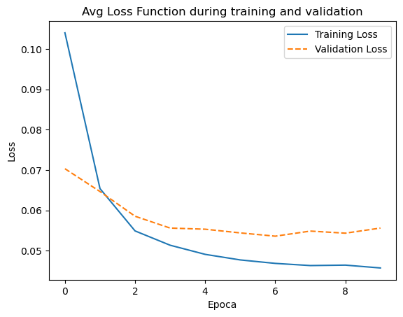

```python
# Avg loss chart
plt.plot(avg_loss_ts, label='Training Loss', linestyle='-')
plt.plot(avg_val_loss_ts, label='Validation Loss', linestyle='--')
plt.title('Avg Loss Function during training and validation')
plt.xlabel('Epoca')
plt.ylabel('Loss')
plt.legend()
plt.show()
```

## B6 Measures performance correctly.

The performance of the model is evaluated using commonly used metrics for regression tasks, namely Mean Squared Error (MSE) and R-squared (R2) score.

- Mean Squared Error (MSE): MSE is calculated using the mean_squared_error function from Scikit-learn, which compares the predicted values (y_ts_pred) with the actual values (y_ts_test) in the test dataset. MSE measures the average squared difference between the predicted and actual values, providing a measure of the model's accuracy. Lower MSE values indicate better model performance.
- Mean Absolute Error (MAE) metric is commonly used to evaluate the accuracy of regression models. It measures the average absolute difference between the predicted values (y_ts_pred) and the actual values (y_ts_test).
- R-squared (R^2) Score: R^2 score is calculated using the r2_score function from Scikit-learn. R^2 score represents the proportion of the variance in the dependent variable (target) that is predictable from the independent variables (features). It ranges from 0 to 1, where 1 indicates a perfect fit and 0 indicates no better prediction than simply predicting the mean of the target values.

These performance metrics provide valuable insights into how well the model generalizes to unseen data and how much of the variance in the target variable is explained by the model's predictions. By calculating both, MAE and R^2 score, the code ensures a comprehensive evaluation of the model's performance on the test dataset.

```python
# Model application
y_pred_test_ts = best_model_ts.predict(x_ts_test)

# Metrics
mse_test_ts = mean_squared_error(y_ts_test, y_pred_test_ts)
mae_test_ts = mean_absolute_error(y_ts_test, y_pred_test_ts)
r2_test_ts = r2_score(y_ts_test, y_pred_test_ts)

# Print
print("Test MSE:", mse_test_ts)
print("Test MAE:", mae_test_ts)
print("Test R^2:", r2_test_ts)
```

```
Test MSE: 0.059171406896551516
Test MAE: 0.19439521168923912
Test R^2: 0.3444784601030739
```

The next cell gives the process of inverse scaling predictions made by a model back to their original scale after they were initially scaled down for model training. This is a common step in data preprocessing for machine learning, especially in time series forecasting, where input features and target variables are often normalized to improve model performance. Let's break down what each part of this code is doing:

#### Inverse scaling

The following code gives the post-process actions for the predictions made by a regression model trained on normalized data. It performs the following key steps:

- Inverse Transformation: Using the inverse of the normalization technique applied during training, the predictions and features are converted back to their original scale. This allows for the interpretation of the model's output in a real-world context. In order to do so, we put the predicted values in the dataframe containing test data (substitution of the target test variable), since, for inverse scaling, the scaler must be used in an item that has the same dimensions of the one on which the initial scaling was performed.
- Evaluation Metrics Calculation: Common regression metrics (MSE, MAE, R²) are computed using the de-normalized predictions and the original values from the test set. These metrics quantify the model's predictive performance on the unaltered data.
- Performance Assessment: The calculated evaluation metrics are printed, enabling a comprehensive assessment of the model's accuracy and predictive power in its native scale.

This process ensures that the model's performance is evaluated in terms of its ability to make meaningful predictions on the original data, providing valuable insights for decision-making and further model refinement.

```python
# Inverse scaling

# simplification
dataset_temp_ts = data_nn_test_ts_norm.copy()
dataset_temp_ts["Wind Onshore(t)"] = y_pred_test_ts
dataset_temp_orig_ts = scaler_ts.inverse_transform(dataset_temp_ts)
dataframe_temp_ts = pd.DataFrame(dataset_temp_orig_ts, columns=dataset_temp_ts.columns)

y_pred_test_origin_ts = dataframe_temp_ts["Wind Onshore(t)"]
reframed_test_without_index = reframed_test.reset_index(drop=True)
y_nn_test_origin_ts = reframed_test_without_index["Wind Onshore(t)"]
```

```python
# de-normalised metrics

# Calculate evaluation metrics on the test set
mse_test_orig_ts = mean_squared_error(y_nn_test_origin_ts, y_pred_test_origin_ts)
mae_test_orig_ts = np.mean(np.abs(y_pred_test_origin_ts - y_nn_test_origin_ts))
r2_test_orig_ts = r2_score(y_nn_test_origin_ts, y_pred_test_origin_ts)

# Print evaluation metrics on the test set
print("\nTest MSE:", mse_test_orig_ts)
print("Test MAE:", mae_test_orig_ts)
print("Test R^2:", r2_test_orig_ts)
```

```
Test MSE: 790236393.2973626
Test MAE: 22465.088243655227
Test R^2: 0.3444784601030739
```

### Interpretation of the evaluation values and conclusion Model B

The relatively high MSE and MAE suggest that the model's predictions are not very close to the actual values, indicating room for improvement in the model's accuracy. The R^2 score being significantly less than 0.5 suggests that the model does not explain a large portion of the variance in the data, which further indicates that the model's predictive power is limited.

Improvement strategies might include exploring more complex model architectures, adding additional or more relevant features, or tuning hyperparameters. Additionally, understanding the context of the predictions (scale and distribution of onshore energy production) and the specific challenges of the dataset (e.g., non-linear relationships, missing data) is crucial for refining the model. is crucial for refining the model.

# 5. C: conclusions

To compare the performances of the two models, we decided to plot some line charts: the first and the second compare singularly the results obtained respectively with model A and model B with the actual ones, while in the last one we put all the charts together in order to understand which of the two performs better.

Before doing this, it is necessary to perform the following step, aimed at arranging arrays' indeces, that will be displayed on the x axis of all the charts and therefore must be alligned. Another operation that needs to be done (in the third chart: "see coordination") is making sure that the three arrays contain the same number of observation: indeed, during feature creation, some rows have been deleted since they contained NaN values; the numbers of rows deleted in model B is different from the one in model A. It is necessary to remove the first five values of model B's prediction (corresponding to the interval between 2023-09-03 and 2023-09-07) in order to have an equal number of values, alligned according to the date.

```python
# setting the correct index
target_nn_test_origin = []

for i, value in enumerate(y_nn_test_origin):
    target_nn_test_origin.append(value)
```

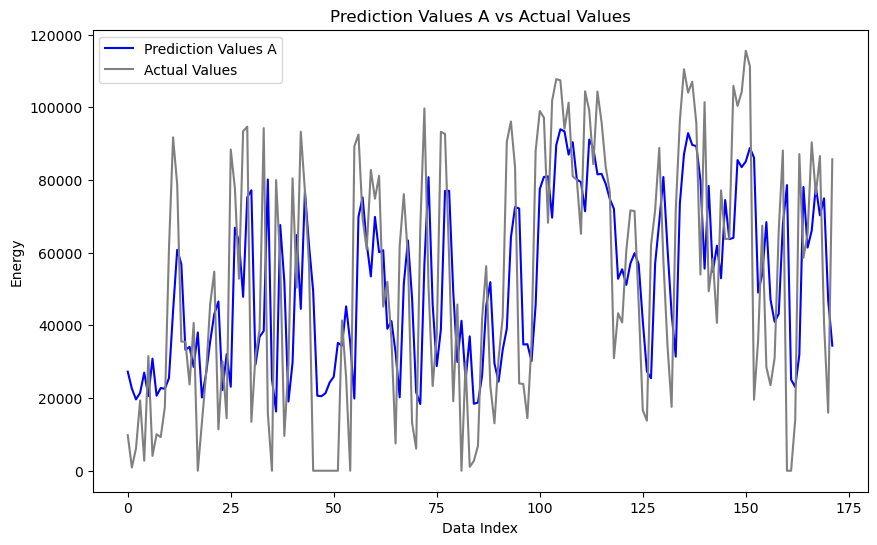

```python
# Predicted Values vs Actual Values: Model A

plt.figure(figsize=(10, 6))

plt.plot(y_pred_test_origin, label='Prediction Values A', color='blue', linestyle='-')
plt.plot(target_nn_test_origin, label='Actual Values', color='grey', linestyle='-')

plt.xlabel('Data Index')
plt.ylabel('Energy')

plt.legend()
plt.title('Prediction Values A vs Actual Values')

plt.show()
```

The predictions follow properly the trend of the actual values. The values are significantly different at the beginning and at the end. In general, it is possible to notice that the model does not detect well the values of peaks and valleys, but in general it efficaciously increase and decrease according to the actual values change. At some points, as we can see between the 25th and the 50th indeces or the 100th and the 125th, the model seems to replicate the trand with a slight delay. In general, it is possible to state that the worst predictions correspond to the moments in actual which energy production is equal to zero.

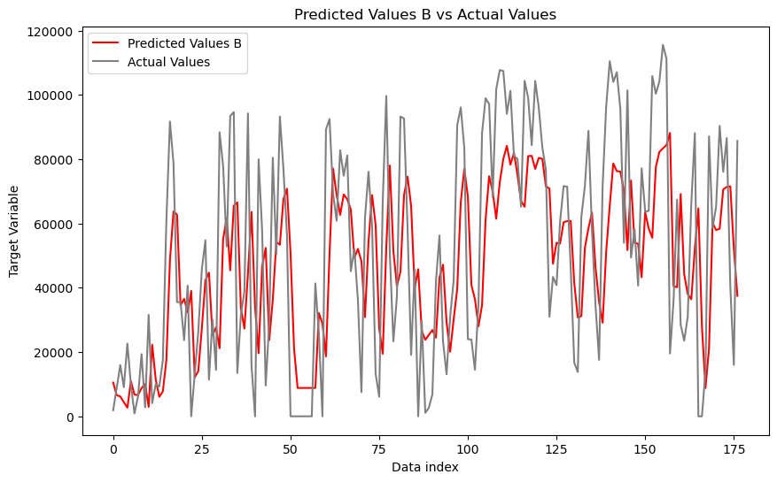

```python
# Predicted Values vs Actual Values: Model B

plt.figure(figsize=(10, 6))

plt.plot(y_pred_test_origin_ts, label='Predicted Values B', color='red', linestyle='-')
plt.plot(y_nn_test_origin_ts, label='Actual Values', color='grey', linestyle='-')

plt.xlabel('Data index')
plt.ylabel('Target Variable')

plt.legend()
plt.title('Predicted Values B vs Actual Values')

plt.show()
```

Model B prediction seems to follow properly the trend of the actual values as well. Even in this case, there are some differences in both the initial and the final part. In general, peaks and valleys are identified well as the values increase and decrease according to the actual measurements, but there is still a significant distance. The zero values around 50th index are represented quite well. The model seems to have slight delays in some parts.

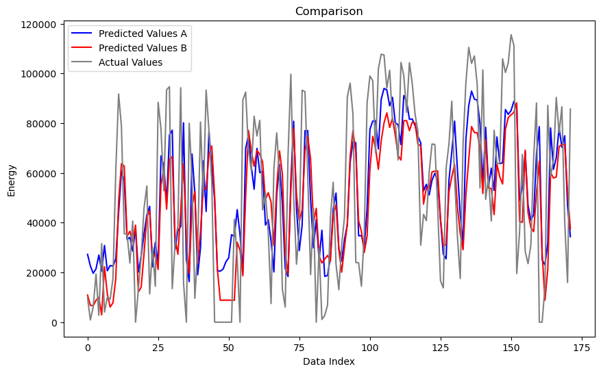

```python
# Comparison

# Coordination
prediction_A = y_pred_test_origin

prediction_B_temp = y_pred_test_origin_ts[5:]
prediction_B = []
for i, value in enumerate(prediction_B_temp):
    prediction_B.append(value)

actual_values = target_nn_test_origin

# Chart
plt.figure(figsize=(10, 6))

# Plot Model A results
plt.plot(prediction_A, label='Predicted Values A', color='blue', linestyle='-')

# Plot Model B results
plt.plot(prediction_B, label='Predicted Values B', color='red', linestyle='-')

# Actual results
plt.plot(actual_values, label='Actual Values', color='grey', linestyle='-')

plt.xlabel('Data Index')
plt.ylabel('Energy')

plt.legend()
plt.title('Comparison')

plt.show()
```

Overall, the performances of the two different models can be visualised on this chart. The initial part is better detected by model B, the final one by model A, even if values are quite far from the actual ones. Considering the representation, it seems that model B better detects valley, while model A generally is closer to reality when dealing with peaks: this is mainly visible after the 100th index. A further confirmation of this comes from the zero values (for example, the ones around the 50th index). Both the models seem to have delays at some points.

In general, for this kind of problems, we could expect better performances from the LSTM model, as it should be able to keep or forgetting ong term dependancies. However, as previously stated, it does not replicate the actual values preciseluy in every occasion. As the models are built, it is not possible to specify which one is the best, as the performances of both of them should be furtherly improved, as confirmed for exampleby the similar values of the coefficeints of determination. With a wider availability of computational power and time, it could be possible to implement a more optimised version of the two neural networks (for example, starting by analysing a larger set of parameters to optimise or modify the features that has been used for this task).